# Assigment 1 - Predictive Modeling

The goal of this project is to apply statistical techniques to analyze and predict outcomes using two datasets. The first part focuses on linear regression with a continuous target variable, while the second part explores Generalized Linear Models (GLM) for more complex predictive tasks involving binary variables.

For the linear regression section, a dataset containing life expectancy and other socio-economic indicators for 217 countries will be used to study and understand the relationship between the variables and create a model with robust predictive capabilities.

The second section employs GLM to analyze data from a telecommunications company. The task is to predict whether a customer will make a purchase in the following month. This involves handling binary outcomes, preparing the dataset effectively, and ensuring accurate predictions through appropriate modeling and evaluation techniques.

Only the essential code snippets are presented in this report for clarity and brevity. For the complete code and implementation details, please refer to the accompanying RMarkdown file.

# LINEAR REGRESSION

Life expectancy is a critical indicator of a country’s overall health and socioeconomic development. This project aims to build a linear regression model to predict the life expectancy based on various socio-economic and health-related factors, including GDP per capita, infant mortality rate, fertility rate, access to electricity, and urban population.

```r
countries <- read.csv("D:/1.Universidad/Predictive modeling/Countries.csv")
```

This dataset was obtained through the World Bank API using a Jupyter Notebook, and the code used for its creation is available in the “Api_Predictive_modeling.ipynb” file. The dataset was created by selecting the variables considered relevant and appropriate for the objectives of this project for the year 2021. The variables are:

- **iso2code**: The two-letter country code used to identify each country.
- **Name** : Name of the country.
- **Population**: The total population of the country in 2021.
- **Infant_mortality**: The infant mortality rate (number of infant deaths per 1,000 live births).
- **Expend_health**: Current health expenditure per capita (current US$).
- **GPD_capita**: GDP per capita (current US$).
- **Fertility_rate**: The average number of children born per woman.
- **Urban_Population**: The percentage of the population living in urban areas.
- **Density**: The population density, measured as people per square kilometer.
- **Drinking_water**: The percentage of the population using at least basic drinking water services.
- **Access_electricity**: The percentage of the population with access to electricity.
- **Internet**: The percentage of the population using the internet.
- **Unemployment**: The unemployment rate, measured as a percentage of the labor force.
- **CO2**: Total carbon dioxide (CO2) emissions.
- **Life_expectancy**: Life expectancy at birth. Target variable.

## Data preparation and exploratory analysis

```r
skim(countries)
```

Data summary

| Name | countries |
| --- | --- |
| Number of rows | 217 |
| Number of columns | 15 |
| _______________________ |  |
| Column type frequency: |  |
| character | 2 |
| numeric | 13 |
| ________________________ |  |
| Group variables | None |

**Variable type: character**

| skim_variable | n_missing | complete_rate | min | max | empty | n_unique | whitespace |
| --- | --- | --- | --- | --- | --- | --- | --- |
| iso2Code | 1 | 1 | 2 | 2 | 0 | 216 | 0 |
| name | 0 | 1 | 4 | 30 | 0 | 217 | 0 |

**Variable type: numeric**

| skim_variable | n_missing | complete_rate | mean | sd | p0 | p25 | p50 | p75 | p100 | hist |
| --- | --- | --- | --- | --- | --- | --- | --- | --- | --- | --- |
| Population | 0 | 1.00 | 36246434.62 | 140510817.61 | 11204.00 | 804567.00 | 6703799.00 | 25685412.00 | 1.412360e+09 | ▇▁▁▁▁ |
| Life_expectancy | 7 | 0.97 | 71.76 | 7.66 | 52.52 | 66.12 | 72.46 | 77.17 | 8.553000e+01 | ▁▅▆▇▆ |
| Infant_mortality | 21 | 0.90 | 19.82 | 18.20 | 1.40 | 5.18 | 12.75 | 30.45 | 7.810000e+01 | ▇▂▂▁▁ |
| Expend_health | 31 | 0.86 | 1384.49 | 2239.34 | 17.64 | 101.59 | 416.95 | 1411.54 | 1.201224e+04 | ▇▁▁▁▁ |
| GDP_capita | 9 | 0.96 | 20342.93 | 31119.22 | 221.16 | 2603.57 | 7359.04 | 26829.39 | 2.351328e+05 | ▇▁▁▁▁ |
| Fertility_rate | 7 | 0.97 | 2.51 | 1.24 | 0.77 | 1.58 | 2.03 | 3.23 | 6.820000e+00 | ▇▅▃▁▁ |
| Urban_Population | 2 | 0.99 | 61.73 | 23.80 | 13.46 | 43.00 | 62.97 | 81.42 | 1.000000e+02 | ▅▆▇▇▇ |
| Density | 1 | 1.00 | 442.04 | 1979.30 | 0.14 | 40.36 | 94.43 | 233.92 | 2.080627e+04 | ▇▁▁▁▁ |
| Drinking_water | 19 | 0.91 | 89.63 | 15.10 | 35.31 | 85.40 | 96.99 | 99.88 | 1.000000e+02 | ▁▁▁▁▇ |
| Access_electricity | 2 | 0.99 | 87.18 | 23.57 | 7.70 | 87.10 | 100.00 | 100.00 | 1.000000e+02 | ▁▁▁▁▇ |
| Internet | 27 | 0.88 | 67.88 | 25.50 | 9.64 | 49.96 | 75.65 | 87.39 | 1.000000e+02 | ▂▃▂▆▇ |
| Unemployment | 30 | 0.86 | 8.06 | 6.00 | 0.14 | 4.03 | 6.04 | 10.50 | 3.571000e+01 | ▇▃▂▁▁ |
| CO2 | 14 | 0.94 | 180.87 | 979.53 | 0.00 | 1.69 | 11.64 | 59.58 | 1.271766e+04 | ▇▁▁▁▁ |

Before splitting the dataset into training and test sets, countries with missing values in the target variable (`Life_expectancy`) are removed. This decision ensures that observations with an unknown target value are neither used for training nor for prediction, as they lack the necessary outcome variable. Additionally, variables related to country names were removed, as they do not contribute meaningful information for prediction.

```r
countries2 <- countries %>%
  dplyr::filter(!is.na(Life_expectancy)) %>%
  dplyr::select(-1, -2)
```

Next, the dataset is split into a training set and a test set, with 80% of the data allocated to the training set and 20% to the test set. This proportion was chosen due to the limited size of the dataset, ensuring that the maximum number of observations are available for training while still reserving a sufficient portion for testing. The training set will be used for descriptive analysis, variable selection, and model development, while the test set will be reserved exclusively for evaluating the performance of the final models. This ensures an unbiased assessment of the models’ predictive capabilities.

```r
set.seed(100452928)
data_split <- initial_split(countries2, prop = 0.8, strata = Life_expectancy)
countries_train <- training(data_split)
countries_test <- testing(data_split)
```

After the partition the training set contains 166 instances while the testing set contains 44 instances.

### Target variable

The first step in the analysis focuses on exploring the target variable, `Life_expectancy`, to understand its distribution and key characteristics. Additionally, its relationship with other variables in the dataset is examined to identify potential patterns, correlations, and trends.

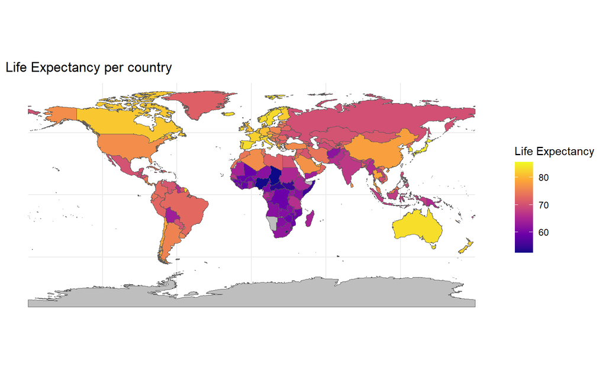

The map illustrates the **Life expectancy** across different countries worldwide. Countries are color-coded based on their average life expectancy, with a gradient ranging from purple (lower life expectancy) to yellow (higher life expectancy). Regions in sub-Saharan Africa exhibit significantly lower life expectancy, as represented by darker shades of purple, while regions in Western Europe, North America, and parts of East Asia show higher life expectancy, indicated by bright yellow hues.

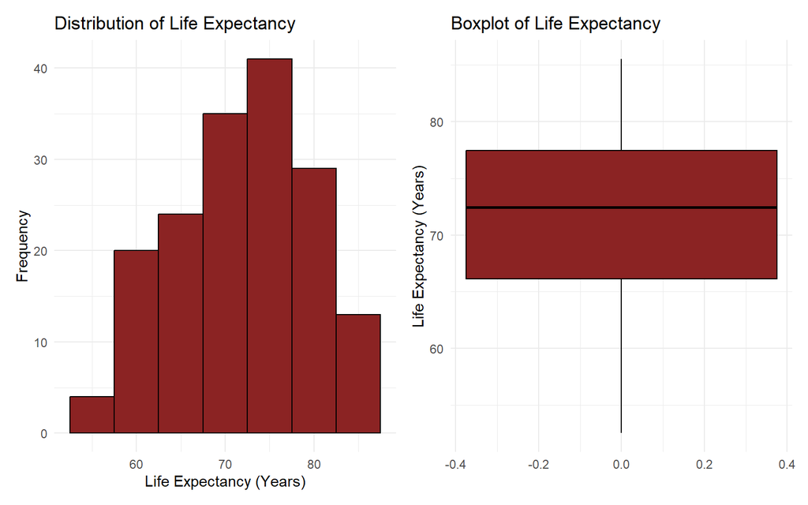

```r
hist_target <- ggplot(countries_train, aes(x = Life_expectancy)) +
  geom_histogram(binwidth = 5, fill = "brown4", alpha = 1, color = "black") +
  labs(
    title = "Distribution of Life Expectancy",
    x = "Life Expectancy (Years)",
    y = "Frequency"
  ) +
  theme_minimal()

# Boxplot
boxplot_target <- ggplot(countries_train, aes(y = Life_expectancy)) +
  geom_boxplot(fill = "brown4", color = "black", alpha = 1) +
  labs(
    title = "Boxplot of Life Expectancy",
    y = "Life Expectancy (Years)"
  ) +
  theme_minimal()


hist_target + boxplot_target
```

This graphs show the distribution of the target variable, `Life Expectancy`. The histogram suggests that the variable may follow a normal distribution, indicating that no transformations will be required. The boxplot reveals that the median is approximately 70–75 years and that there are no apparent outliers, further confirming that most countries fall within a similar range. To formally assess the normality of the variable, a **Kolmogorov-Smirnov** test can be applied. This analysis supports the suitability of the variable for use in linear regression modeling without the need for adjustments.

$$H_0: Life\ expectancy\ comes\ from\ a\ normal\ distribution$$

$$H_1: Life\ expectancy\ does\ not\ come\ from\ a\ normal\ distribution$$

```r
ks_result <- ks.test(countries_train$Life_expectancy, "pnorm",
                     mean(countries_train$Life_expectancy),
                     sd(countries_train$Life_expectancy))
```

Kolmogorov-Smirnov Test Results

| statistic | p.value | method | alternative | Interpretation |
| --- | --- | --- | --- | --- |
| 0.0587615 | 0.6152456 | Asymptotic one-sample Kolmogorov-Smirnov test | two-sided | Data likely follows a normal distribution |

Now it can be explored the relationship of the target variable with predictor variables.

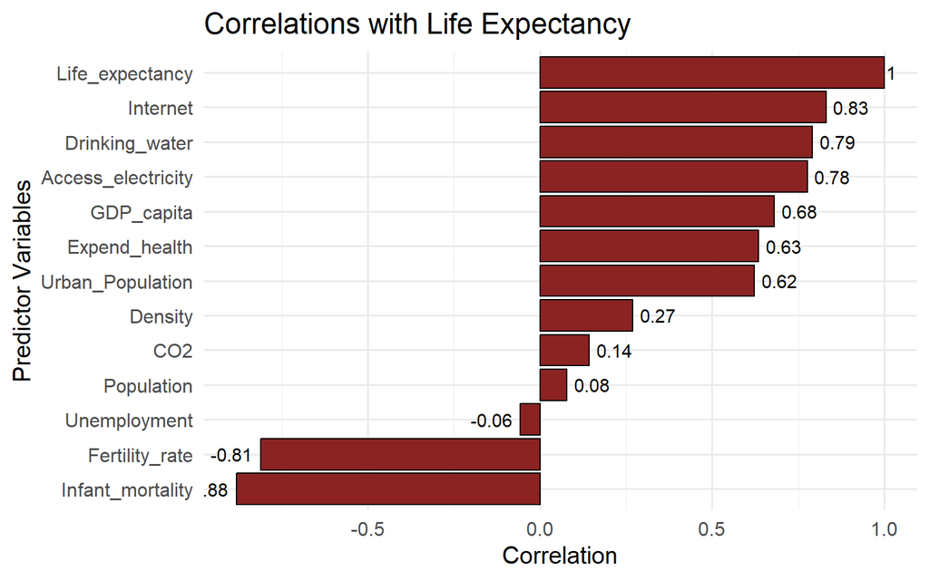

```r
ggplot(correlation_df, aes(x = reorder(Variable, Correlation), y = Correlation)) +
  geom_bar(stat = "identity", fill = "brown4", color = "black", alpha = 1) +
  geom_text(
    aes(label = round(Correlation, 2)),
    hjust = ifelse(correlation_df$Correlation > 0, -0.2, 1.2),
    color = "black",
    size = 4
  ) +
  coord_flip() +
  labs(
    title = "Correlations with Life Expectancy",
    x = "Predictor Variables",
    y = "Correlation"
  ) +
  theme_minimal(base_size = 15)
```

The graph shows that variables like `Internet`, `Drinking_water`, `Access_electricity`, and `GDP_capita` exhibit strong positive correlations with life expectancy, suggesting that higher values of these predictors are associated with longer life expectancy. Conversely, `Infant_mortality` and `Fertility_rate` show strong negative correlations with life expectancy, indicating that higher values of these variables are associated with shorter life expectancy. Other variables such as `Unemployment` and `Population` show weak or negligible correlations, which may imply they have limited direct influence on life expectancy.

Once the individual correlations with the response variable have been identified, we can examine each predictor variable separately.

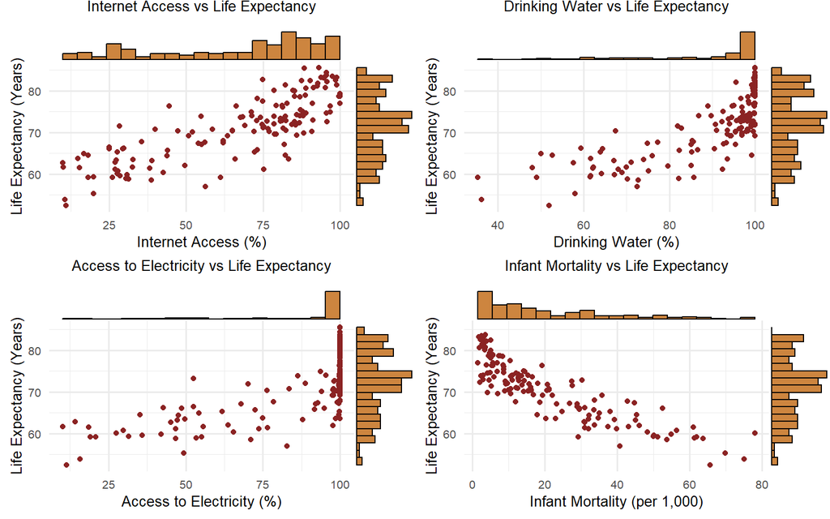

```r
create_scatter_with_marginals <- function(data, x_var, x_label, title) {
  scatter_plot <- ggplot(data, aes_string(x = x_var, y = "Life_expectancy")) +
    geom_point(color = "brown4", alpha = 1) +
    labs(
      title = title,
      x = x_label,
      y = "Life Expectancy (Years)"
    ) +
   theme_minimal(base_size = 12) +
    theme(
      plot.title = element_text(size = 10, hjust = 0.5) ,
      axis.title = element_text(size = 10),
      axis.text = element_text(size = 8)
    )

  ggMarginal(scatter_plot, type = "histogram", fill = "tan3", bins = 20)
}
```

The scatterplots above describe the relationships between four variables and life expectancy, while also showing the distribution of each variable along the margins.

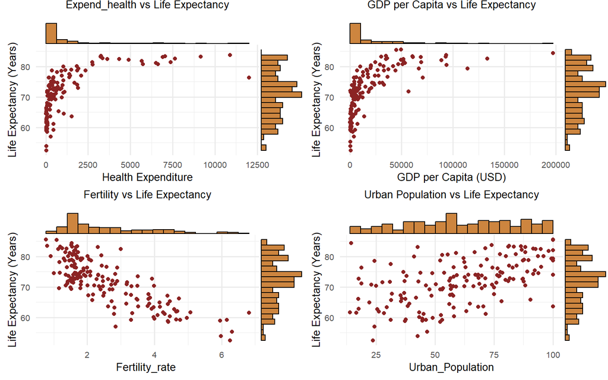

```r
plot_grid(g5, g4, g7, g8, nrow = 2, align = "v")
```

- **Fertility rate:** There is a clear negative correlation between fertility rate and life expectancy (-0.81) as higher fertility rates tend to be associated with lower life expectancy. The fertility rate distribution is concentrated around 1–3 children per woman, with fewer countries showing very high rates.
- **Urban population:** A positive relationship is observed between the percentage of the population living in urban areas and life expectancy (0.62), though the relationship appears weaker compared to the other variables.
- **Health expenditure:** There is a positive relationship between health expenditure and life expectancy, as seen in the increasing trend. However, the relationship is nonlinear, particularly at higher expenditure values where life expectancy plateaus.
- **GDP capita:** A similar nonlinear trend is observed, where life expectancy increases with GDP per capita but flattens for wealthier countries.

To address the issue of non-linearity in the last two variables, applying a **logarithmic transformation** can be considered to assess whether it results in a more linear relationship.

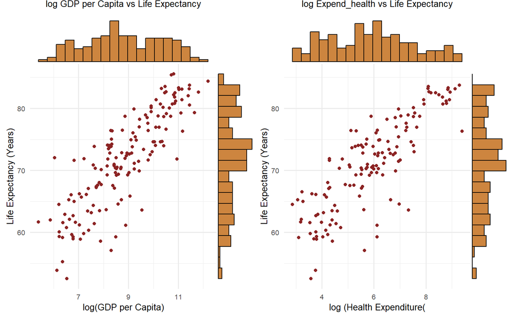

The **logarithmic transformation** of GDP per capita and health expenditure reveals a more linear relationship with life expectancy compared to the original scale. For GDP per capita, the transformation captures the diminishing returns of wealth on life expectancy, especially in wealthier countries. Similarly, for health expenditure, the logarithmic scale better illustrates the relationship, suggesting a more proportional increase in life expectancy with rising expenditure. This transformations have to be considered in the creation of the models.

### Predictor Variables

After analyzing the target variable and its relationship with the predictor variables, the focus shifts to examining the predictor variables themselves. This step aims to understand the relationships between them, identify patterns, and detect potential issues such as multicollinearity, which could impact the performance and interpretability of the regression models.

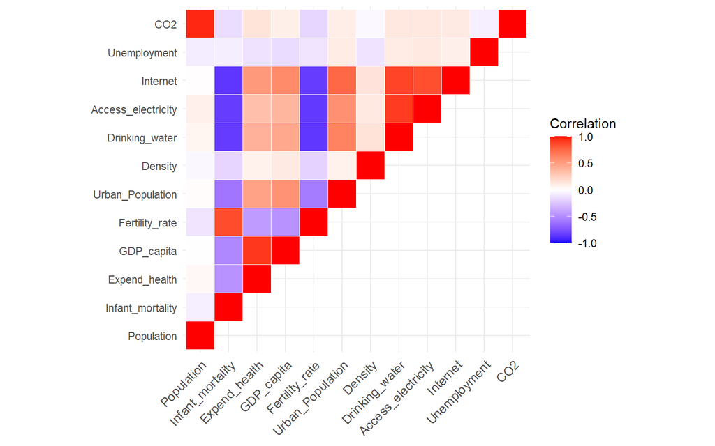

```r
ggplot(correlation_melt_upper, aes(x = Var1, y = Var2, fill = value)) +
  geom_tile(color = "white") +
  scale_fill_gradient2(low = "blue", high = "red", mid = "white",
                       midpoint = 0, limit = c(-1, 1), space = "Lab",
                       name = "Correlation") +
  theme_minimal() +
  theme(axis.text.x = element_text(angle = 45, vjust = 1,
                                   size = 10, hjust = 1),
        axis.title.x = element_blank(),
        axis.title.y = element_blank()) +
  coord_fixed()
```

The heatmap visually represents the strength and direction of the linear relationships between the variables. Red indicates a strong positive correlation, while blue signifies a strong negative correlation. Variables such as `CO2` and `Population`, or `Internet` and `Drinking_water`, show highly correlated pairs, as reflected by the intensity of their colors.

Highly Correlated Predictor Variables

| Variable 1 | Variable 2 | Correlation Value |
| --- | --- | --- |
| CO2 | Population | 0.9558088 |
| GDP_capita | Expend_health | 0.9161082 |
| Access_electricity | Drinking_water | 0.9039125 |
| Internet | Drinking_water | 0.8807430 |
| Internet | Infant_mortality | -0.8610041 |
| Drinking_water | Fertility_rate | -0.8568235 |
| Fertility_rate | Infant_mortality | 0.8537593 |
| Access_electricity | Fertility_rate | -0.8481329 |
| Internet | Access_electricity | 0.8459838 |
| Drinking_water | Infant_mortality | -0.8399231 |
| Internet | Fertility_rate | -0.8365026 |
| Access_electricity | Infant_mortality | -0.8356466 |

The table lists the **most strongly correlated** variable pairs, with correlation values exceeding a threshold of 0.8.

The analysis of correlations highlights several significant relationships between variables. `CO2` and `Population` show a **very strong positive correlation (0.96)**, indicating that larger populations are a key driver of emissions. Similarly, `GDP_capita` and `Expend_health` are **highly correlated (0.91)**, suggesting that economic indicators and health expenditure are closely linked. In this case, GDP per capita appears to be a more robust predictor due to its stronger correlation with the target variable and fewer missing values.

Additionally, variables such as `Access_electricity`, `Drinking_water`, `Internet`, `Fertility_rate`, and `Infant_mortality` exhibit strong relationships among themselves. For instance, `Internet` and `Drinking_water` have a correlation of 0.88, while `Infant_mortality` is negatively correlated with `Internet` (-0.86) and positively correlated with `Fertility_rate` (0.85). These relationships indicate shared underlying socioeconomic and infrastructure influences.

To improve model interpretability and avoid multicollinearity issues:

- `CO2` will be **excluded**, as `Population` is a strong determinant of emissions and is already included in the dataset.
- `Expend_health` will also be **removed** because `GDP_capita` shows a stronger correlation with the target variable and has fewer missing values, making it a more reliable predictor.

Despite the high correlations observed among variables such as `Access_electricity`, `Drinking_water`, `Internet`, `Fertility_rate`, and `Infant_mortality`, no additional variables will be excluded at this stage. While their relationships suggest potential multicollinearity, it is not yet certain which variables will prove most significant in predicting life expectancy. However, this issue must be carefully considered to avoid overfitting during the modeling process. Techniques such as **LASSO** regression will be explored to address multicollinearity and ensure the development of robust and interpretable models.

### Missing Values

The next step in the descriptive analysis is to examine the presence of **missing values** in the dataset, identify the variables affected, and determine the most appropriate strategy to handle them. Understanding the distribution of missing values is crucial, as their presence can introduce bias, reduce statistical power, and negatively impact model performance.

```r
missing_values <- countries_train %>%
  dplyr::summarise(across(everything(), ~ sum(is.na(.)))) %>%
  pivot_longer(cols = everything(), names_to = "Variable", values_to = "Missing_Count")
```

Summary of Missing Values in the Dataset

| Variable | Missing Count |
| --- | --- |
| Expend_health | 26 |
| Unemployment | 22 |
| Internet | 21 |
| Infant_mortality | 17 |
| Drinking_water | 14 |
| GDP_capita | 7 |
| CO2 | 7 |
| Fertility_rate | 1 |
| Urban_Population | 1 |
| Population | 0 |
| Life_expectancy | 0 |
| Density | 0 |
| Access_electricity | 0 |

The table summarizes the variables with missing values and their respective counts. Given the relatively high number of missing values and the limited number of instances in the dataset, removing rows or columns with missing data is not a viable option, as it would result in significant loss of information. Instead, an appropriate **imputation** strategy will be employed to fill in the missing values. This approach ensures that the dataset remains as complete and representative as possible, preserving its utility for accurate modeling.

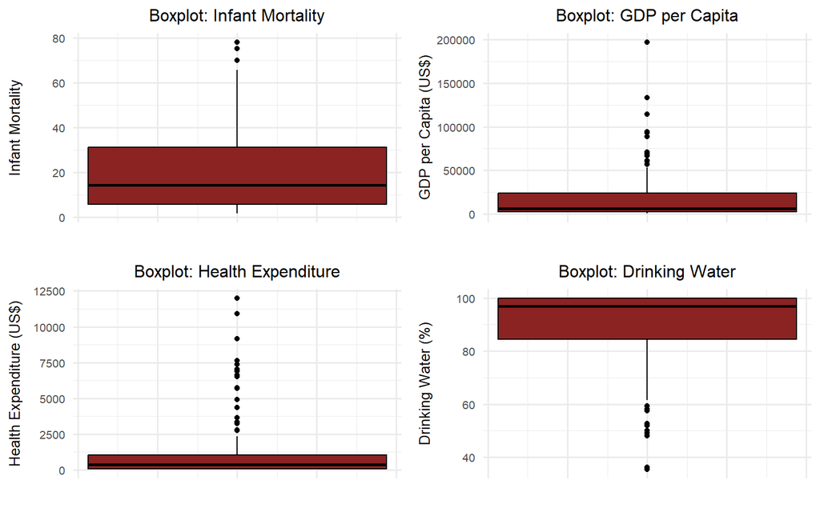

```r
create_boxplot <- function(data, var, var_label, title) {
  ggplot(data, aes_string(y = var)) +
    geom_boxplot(fill = "brown4", color = "black", alpha = 1) +
    labs(
      title = title,
      y = var_label,
      x = ""
    ) +
    theme_minimal(base_size = 12) +
    theme(
      plot.title = element_text(size = 12, hjust = 0.5),
      axis.title.y = element_text(size = 10),
      axis.text.y = element_text(size = 8),
      axis.text.x = element_blank(),
      axis.ticks.x = element_blank()
    )
}

g1 <- create_boxplot(countries_train, "Infant_mortality", "Infant Mortality", "Boxplot: Infant Mortality")
g2 <- create_boxplot(countries_train, "GDP_capita", "GDP per Capita (US$)", "Boxplot: GDP per Capita")
g3 <- create_boxplot(countries_train, "Expend_health", "Health Expenditure (US$)", "Boxplot: Health Expenditure")
g4 <- create_boxplot(countries_train, "Drinking_water", "Drinking Water (%)", "Boxplot: Drinking Water")

plot_grid(g1, g2, g3, g4, nrow = 2, align = "v")
```

When addressing missing values, simple imputation using the **median** often appears to be a suitable option, particularly for variables with a large number of outliers, as shown in the boxplots. The median is robust to outliers and provides a central tendency measure that avoids the influence of extreme values.

However, imputing with the median has a drawback because it introduces a **constant value** for missing entries, which can reduce the correlations between variables. This loss of representativeness can weaken the dataset’s ability to capture real-world relationships among variables.

An alternative approach is to **impute** missing values using a **regression model**. This method predicts missing values based on the most related variables, potentially maintaining stronger correlations and a more realistic representation of the data. Both options will be considered depending on the variable’s characteristics and their importance in the predictive models.

### Preprocessing

With all the insights gained from the exploratory data analysis, preprocessing decisions will now be applied systematically using a **pipeline** approach. A pipeline ensures consistency and reproducibility, as it automates sequential data transformations, minimizes manual intervention, and reduces the likelihood of errors. Moreover, this approach ensures that the same preprocessing steps are applied consistently to both the training and test datasets, avoiding data leakage and ensuring fair model evaluation.

The steps are:

```r
impute_with_model <- function(data, variable, formula) {

  model <- lm(as.formula(formula), data = data, na.action = na.exclude)

  data[[variable]][is.na(data[[variable]])] <- predict(model, newdata = data[is.na(data[[variable]]), ])

  return(data)
}

impute_median <- function(data, columns) {
  data %>%
    dplyr::mutate(across(
      .cols = all_of(columns),
      .fns = ~ ifelse(is.na(.), median(., na.rm = TRUE), .)
    ))
}

remove_unwanted_columns <- function(data) {
  data %>% dplyr::select(-c(CO2, Expend_health))
}
```

```r
preprocess_data <- function(data) {
  data <- impute_median(data, c("Fertility_rate", "Urban_Population"))

  data <- impute_with_model(data, "Internet", "Internet ~  Access_electricity + Fertility_rate")

  data <- impute_with_model(data, "Drinking_water", "Drinking_water ~  Internet  ")

  data <- impute_with_model(data, "GDP_capita", "GDP_capita ~ Population + Urban_Population + Internet + Drinking_water + CO2")

  data <- impute_with_model(data, "Unemployment", "Unemployment ~ GDP_capita   ")

  data <- impute_with_model(data, "Infant_mortality", "Infant_mortality ~ Drinking_water + Internet + Access_electricity  + Fertility_rate ")

  data <- remove_unwanted_columns(data)

  data <- data %>%
    dplyr::mutate(across(where(is.numeric), ~ ifelse(is.na(.), median(., na.rm = TRUE), .)))

  return(data)
}

countries_train2 = preprocess_data(countries_train)
```

Summary of Missing Values in the Dataset

| Variable | Missing Count |
| --- | --- |
| Population | 0 |
| Life_expectancy | 0 |
| Infant_mortality | 0 |
| GDP_capita | 0 |
| Fertility_rate | 0 |
| Urban_Population | 0 |
| Density | 0 |
| Drinking_water | 0 |
| Access_electricity | 0 |
| Internet | 0 |
| Unemployment | 0 |

As we can see the number of **missing values** is **0** in all the columns and the same preprocessing is applied to the test set.

```r
countries_test2 = preprocess_data(countries_test)
```

## Predictive analysis

The next step involves transitioning from exploratory data analysis to **predictive modeling**. In this phase, various regression models and techniques will be explored to identify the best approach for predicting `Life_expectancy`. The focus is not only on achieving high predictive accuracy but also on ensuring that the model generalizes well to unseen data, avoiding overfitting. Techniques such as **feature selection** and **LASSO regression** will be applied to address multicollinearity and improve model performance. The goal is to strike a **balance** between **simplicity** and **predictive power**, ensuring the model is interpretable and reliable.

In this analysis, the **adjusted** $R^2$ will be prioritized over the regular $R^2$ for model evaluation. While the regular $R^2$ increases with the addition of predictors regardless of their relevance, the adjusted $R^2$ penalizes the inclusion of non-informative variables, providing a more accurate measure of the model’s explanatory power when multiple predictors are used.

### Models by hand

The first step in the predictive analysis involves exploring models manually, leveraging the insights gained from the exploratory data analysis.

Evaluation of the models will focus on examining both the $R^2$ adjusted values for the training and test datasets, as well as the statistical significance of the predictors. Additionally, meaningful diagnostic plots and visualizations will be presented to comprehensively assess the models’ performance and understand their behaviour.

#### Internet

The process begins with a simple model that includes only the variable `Internet`, as it showed the strongest correlation with the response variable `Life_expectancy`. This approach allows for a gradual understanding of how adding or modifying variables impacts the model’s performance and generalization.

$$Life\ expectancy = B_0 + B_1*Internet$$

```r
lr_spec <- linear_reg() %>%
  set_engine("lm") %>%
  set_mode("regression")

lr_fit <- lr_spec %>%
  fit(
    Life_expectancy ~ Internet,
    data = countries_train2
  )

summ(lr_fit$fit, digits = 3)
```

| Observations | 166 |
| --- | --- |
| Dependent variable | Life_expectancy |
| Type | OLS linear regression |

| F(1,164) | 286.052 |
| --- | --- |
| R² | 0.636 |
| Adj. R² | 0.633 |

|  | Est. | S.E. | t val. | p |
| --- | --- | --- | --- | --- |
| (Intercept) | 55.583 | 1.019 | 54.553 | 0.000 |
| Internet | 0.237 | 0.014 | 16.913 | 0.000 |

Standard errors: OLS

```r
test_predictions <- predict(lr_fit, new_data = countries_test2) %>%
  bind_cols(countries_test2)

pred <- test_predictions$.pred
real <- test_predictions$Life_expectancy

train_model <- lr_fit$fit
summary_train <- summary(train_model)
R2_train <- summary_train$adj.r.squared

# With the formula

SSE <- sum((real - pred)^2)
SST <- sum((real - mean(real))^2)
R2_test <- 1 - (SSE / SST)
n <- nrow(countries_test2)
p <- length(lr_fit$preproc$term_info$variable) - 1
R2_adj <- 1 - ((1 - R2_test) * (n - 1) / (n - p - 1))

mae <- mean(abs(pred - real))
rmse <- sqrt(mean((pred - real)^2))
metrics_table <- tibble::tibble(
  Metric = c("R² Train", "R² Test", "MAE", "RMSE"),
  Value = c(R2_train, R2_adj, mae, rmse)
)
```

Performance Metrics for Internet Model

| Metric | Value |
| --- | --- |
| R² Train | 0.6334 |
| R² Test | 0.6007 |
| MAE | 4.2201 |
| RMSE | 5.2572 |

The model using `Internet` as the sole predictor for `Life_expectancy` demonstrates a strong fit, with an adjusted $R^2$ of **0.63** for the training dataset meaning that Internet access alone explains 63% of the variability in life expectancy and **0.60** for the test dataset. These similar adjusted $R^2$ values indicate that the model generalizes well to unseen data, suggesting a consistent relationship between internet usage and life expectancy across the datasets.

The predictor `Internet` is highly significant (p<0.001), with a positive coefficient of 0.24, implying that for each 1% increase in internet access, the expected life expectancy increases by 0.24 years. This result highlights the potential of internet access as a key socio-economic factor influencing health outcomes globally.

Next, various models have been tested by adding different combinations of predictors to identify the most relevant variables for predicting life expectancy. The results of these models, focusing on the most impactful and statistically significant predictors, are presented below.

#### Internet + GDP_capita + Access_electricity + Fertility_rate + Drinking_water

The next model is the following one:

$$Life\ expectancy = B_0 + B_1*Internet + B_2 * GDP\ capita + B_3 *
Access\ Electricity \\+ B_4 * Fertility\ Rate + B_5 * Drinking\ Water$$

| Observations | 166 |
| --- | --- |
| Dependent variable | Life_expectancy |
| Type | OLS linear regression |

| F(5,160) | 114.392 |
| --- | --- |
| R² | 0.781 |
| Adj. R² | 0.775 |

|  | Est. | S.E. | t val. | p |
| --- | --- | --- | --- | --- |
| (Intercept) | 65.596 | 3.993 | 16.427 | 0.000 |
| Internet | 0.041 | 0.028 | 1.471 | 0.143 |
| GDP_capita | 0.000 | 0.000 | 7.347 | 0.000 |
| Access_electricity | 0.030 | 0.025 | 1.199 | 0.232 |
| Fertility_rate | -2.236 | 0.430 | -5.197 | 0.000 |
| Drinking_water | 0.055 | 0.050 | 1.098 | 0.274 |

Standard errors: OLS

The adjusted $R^2$ for the training dataset is **0.77**, while for the test dataset it is **0.75**. This close alignment between training and test performance indicates that the model generalizes well to unseen data, demonstrating its reliability and shows the improvement from the previous model. The overall model is significant as $F(5,160) = 114.39$ and $p < 0.001$.

```r
metrics_table %>%
  kable(
    caption = "Performance Metrics for some variables Model",
    col.names = c("Metric", "Value"),
    digits = 4,
    align = c("l", "c")
  ) %>%
  kable_styling(bootstrap_options = c("striped", "hover", "condensed"), full_width = FALSE)
```

Performance Metrics for some variables Model

| Metric | Value |
| --- | --- |
| R² Train | 0.7746 |
| R² Test | 0.7557 |
| MAE | 3.0610 |
| RMSE | 4.1118 |

**Model Coefficients:**

- **Internet:** 0.04. For each 1% increase in internet access, life expectancy increases by 0.04 years. However, this relationship is not statistically significant (p-value = 0.14).
- **GDP per capita**: 0.00. For every one-unit increase in GDP per capita (measured in USD), life expectancy increases slightly but significantly (p-value < 0.001).
- **Access to electricity**: 0.03. A 1% increase in electricity access is associated with a 0.03-year increase in life expectancy, but this relationship is not statistically significant (p-value = 0.23).
- **Fertility rate**: -2.24. For every one-unit increase in fertility rate, life expectancy decreases by 2.24 years, and this effect is statistically significant (p-value < 0.001).
- **Access to drinking water** : 0.06. A 1% increase in access to drinking water is associated with a 0.06-year increase in life expectancy, but this effect is not statistically significant (p-value = 0.27).

### Interactions

Lastly a model with **interactions** is shown.

- **Unemployment × GDP per capita:** This interaction term captures how the relationship between unemployment and life expectancy changes depending on the level of GDP per capita. It allows the model to account for the combined effect of these two economic indicators.
- **Internet × Drinking water:** This interaction term represents how the effect of internet usage on life expectancy varies based on access to drinking water. Notably, the variable “Drinking water” is not going to appear as a **standalone predictor**.

$$Life\ expectancy = B_0 + B_1*Internet + B_2*Access\ Electricity +
B_3*Fertility\ Rate \\
+ B_4*(Unemployment \times GDP\ capita) + B_5*(Internet : Drinking\
Water)$$

```r
lr_spec <- linear_reg() %>%
  set_engine("lm") %>%
  set_mode("regression")

lr_fit <- lr_spec %>%
  fit(
    Life_expectancy ~ Internet + Access_electricity + Fertility_rate + Unemployment*GDP_capita + Internet:Drinking_water,
    data = countries_train2
  )

summ(lr_fit$fit, digits = 3)
```

| Observations | 166 |
| --- | --- |
| Dependent variable | Life_expectancy |
| Type | OLS linear regression |

| F(7,158) | 96.170 |
| --- | --- |
| R² | 0.810 |
| Adj. R² | 0.801 |

|  | Est. | S.E. | t val. | p |
| --- | --- | --- | --- | --- |
| (Intercept) | 70.354 | 2.612 | 26.931 | 0.000 |
| Internet | -0.243 | 0.095 | -2.559 | 0.011 |
| Access_electricity | 0.049 | 0.021 | 2.281 | 0.024 |
| Fertility_rate | -1.915 | 0.400 | -4.784 | 0.000 |
| Unemployment | -0.123 | 0.053 | -2.333 | 0.021 |
| GDP_capita | 0.000 | 0.000 | 3.532 | 0.001 |
| Unemployment:GDP_capita | 0.000 | 0.000 | 2.956 | 0.004 |
| Internet:Drinking_water | 0.003 | 0.001 | 3.158 | 0.002 |

Standard errors: OLS

Performance Metrics for Interactions Model

| Metric | Value |
| --- | --- |
| R² Train | 0.8015 |
| R² Test | 0.7954 |
| MAE | 2.8298 |
| RMSE | 3.7628 |

The coefficients displayed as 0 are not truly zero, they are very small values that appear as 0 due to rounding. This does not mean that these coefficients lack importance or should be excluded. Even small coefficients can contribute to the model’s predictive performance, particularly when they are statistically significant or capture nuanced relationships, such as interactions. Their inclusion ensures the model accounts for all relevant effects, even those that might seem subtle at first glance.

After analyzing a large number of models manually, this model has provided the best adjusted $R^2$ results without overfitting the data. Overfitting was observed when too many variables with high correlations (identified during the descriptive analysis) were included in the model, leading to a lack of generalization to unseen data. Although the descriptive analysis suggested that applying a logarithmic transformation to GDP per capita would improve its relationship with life expectancy, the performance of the models was significantly worse when using the transformed variable.

Now that the final model has been selected, it is crucial to verify whether the necessary assumptions for linear regression have been met. These assumptions include the **normality** of **residuals**, **homoscedasticity** (constant variance of residuals), **independence of residuals**, and linearity of relationships between predictors and the target variable. To assess these conditions, diagnostic plots were generated and statistical tests were performed:

- **Kolmogorov-Smirnov Test:** This test evaluates whether the residuals follow a normal distribution.
- **Breusch-Pagan Test:** This test checks for homoscedasticity, ensuring that the variance of the residuals remains constant across fitted values.

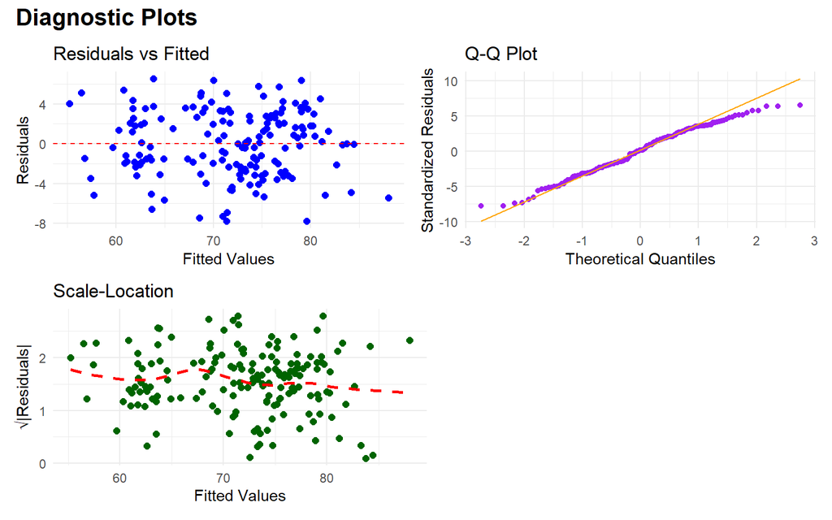

- **Residuals vs. Fitted Plot:** This plot shows no clear patterns, indicating that the assumption of linearity between the predictors and the response variable is satisfied. Additionally, the spread of residuals appears relatively consistent, supporting homoscedasticity.
- **Q-Q Plot:** The points in the Q-Q plot mostly align with the diagonal line, suggesting that the residuals follow a normal distribution.
- **Scale-Location Plot:** The residuals exhibit a fairly consistent spread across fitted values, further confirming the assumption of homoscedasticity.

Diagnostic Test Results

|  | Test | p.value | Conclusion |
| --- | --- | --- | --- |
|  | Kolmogorov-Smirnov Test | 0.4569198 | Residuals likely follow a normal distribution. |
| BP | Breusch-Pagan Test | 0.4810729 | Residuals have constant variance (homoscedasticity). |

The diagnostic plots and statistical tests **confirm** that the model **satisfies** the **key assumptions** of linear regression, including normality of residuals, homoscedasticity, and linearity. No significant issues were identified, validating the robustness and reliability of the selected model.

We can plot some graphs to see the effects of some variables in the model.

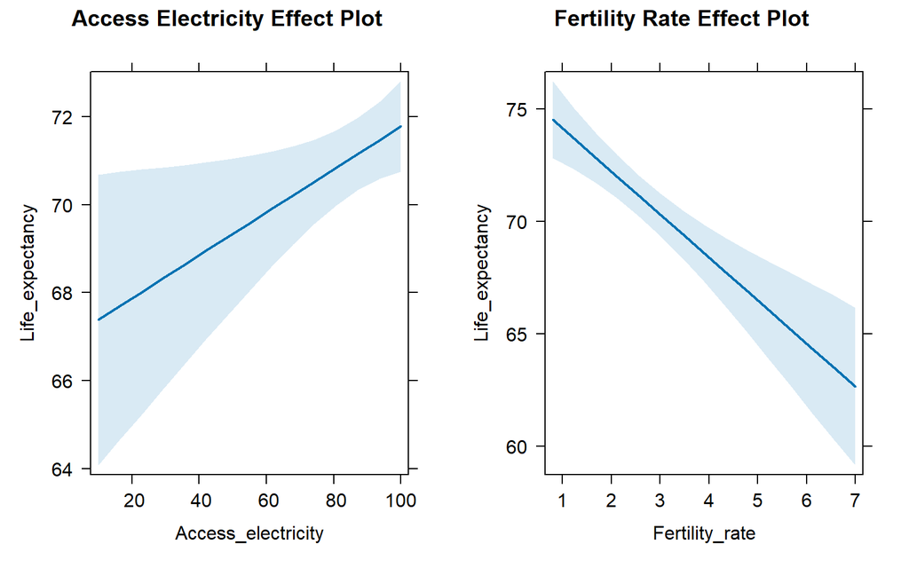

```r
efectos <- allEffects(model3)

p1 <- plot(efectos[["Access_electricity"]], rug = FALSE, main = "Access Electricity Effect Plot", cex.main = 1.5)
p2 <- plot(efectos[["Fertility_rate"]], rug = FALSE, main = "Fertility Rate Effect Plot", cex.main = 1.5)
p3 <- plot(efectos[["Internet:Drinking_water"]], rug = FALSE, main = "Internet x Drinking Water Effect Plot", cex.main = 1.5)

grid.arrange(p1, p2, ncol = 2, nrow = 1)
```

- `Access_electricity`: The plot shows a positive linear relationship between access to electricity and life expectancy, with higher levels of electricity access leading to an increase in life expectancy. The confidence interval (shaded region) narrows for higher electricity access, indicating more consistent predictions in those ranges.
- `Fertility_rate`: The plot demonstrates a strong negative relationship between fertility rate and life expectancy. As the fertility rate increases, life expectancy decreases significantly. The confidence interval widens slightly for higher fertility rates, indicating more variability in predictions at extreme values.

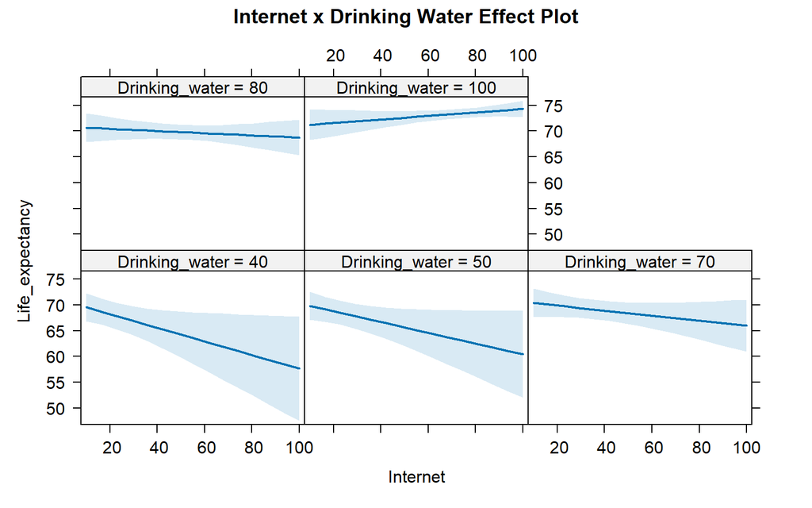

```r
plot(p3)
```

- `Internet` × `Drinking_water`: The panels illustrate how the relationship between internet usage and life expectancy varies depending on access to drinking water. In countries with higher access to drinking water, internet usage has a minimal or slightly positive impact on life expectancy. Conversely, in countries with lower access to drinking water (e.g., 40%), higher internet usage correlates with a decrease in life expectancy. This interaction suggests that internet usage alone cannot significantly improve life expectancy unless accompanied by access to basic necessities such as clean drinking water. In areas with poor water access, internet usage may be less impactful or reflect underlying socioeconomic disparities.

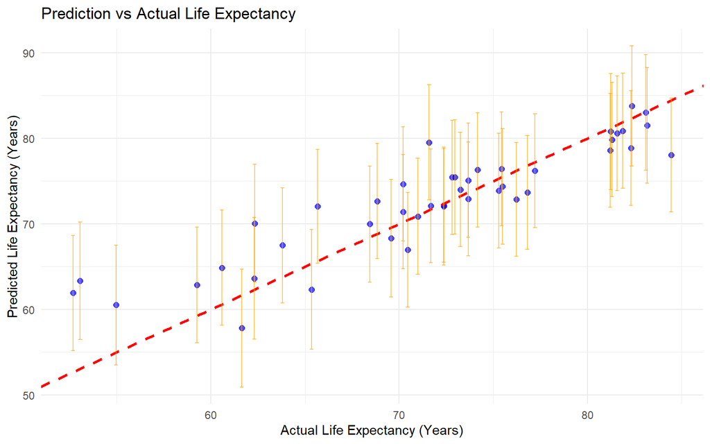

```r
predict_with_intervals <- predict(
  lr_fit$fit,
  newdata = countries_test2,
  interval = "prediction"
)

results <- as_tibble(predict_with_intervals) %>%
  bind_cols(
    actual = countries_test2$Life_expectancy,
    Internet = countries_test2$Internet
  )

ggplot(results, aes(x = actual, y = fit)) +
  geom_point(color = "blue", alpha = 0.7, size = 2) +
  geom_abline(slope = 1, intercept = 0, color = "red", linetype = "dashed", size = 1) +  # Línea ideal
  geom_errorbar(aes(ymin = lwr, ymax = upr), width = 0.2, color = "orange", alpha = 0.6) +
  labs(
    title = "Prediction vs Actual Life Expectancy",
    x = "Actual Life Expectancy (Years)",
    y = "Predicted Life Expectancy (Years)"
  ) +
  theme_minimal()
```

Finally, the plot compares the **predicted life expectancy values** with the **actual observed values**, providing a visual assessment of the model’s predictive performance. The vertical error bars represent **prediction intervals**, which indicate the range where a new observation is likely to fall, considering both the uncertainty of the model and the inherent variability of the data.

The prediction intervals remain fairly consistent in width across most of the life expectancy range. This indicates that the model’s uncertainty in predicting life expectancy does not vary dramatically between lower and higher ranges. However, there are some instances, particularly at the **extremes** (both low and high life expectancy), where prediction intervals slightly widen. This suggests the model may be less confident when making predictions in these ranges, potentially due to fewer data points or greater variability in the training data.

Overall, the predicted values align closely with the diagonal red dashed line, which represents perfect predictions. This indicates that the model is generally accurate across the dataset.

The prediction intervals can also be analyzed numerically and visually:

```r
results <- results %>%
  mutate(Prediction_Interval_Width = upr - lwr)

results <- results %>%
  mutate(Prediction_Interval_Width = upr - lwr)

interval_summary <- data.frame(
  Statistic = c("Min", "1st Quartile", "Median", "Mean", "3rd Quartile", "Max"),
  Value = as.numeric(summary(results$Prediction_Interval_Width))
)

interval_summary %>%
  kable(caption = "Summary of Prediction Interval Widths",
        align = "c") %>%
  kable_styling(bootstrap_options = c("striped", "hover", "condensed"), full_width = FALSE)
```

Summary of Prediction Interval Widths

| Statistic | Value |
| --- | --- |
| Min | 13.27258 |
| 1st Quartile | 13.34238 |
| Median | 13.43407 |
| Mean | 13.50477 |
| 3rd Quartile | 13.54102 |
| Max | 14.23390 |

From the summary table, the prediction interval widths range from 13.27 (minimum) to 14.23 (maximum), with a mean of approximately 13.50. The narrow range of widths confirms that the prediction intervals are relatively consistent across all data points. This suggests that the model treats the uncertainty in its predictions fairly uniformly, which aligns with the overall stability of the model.

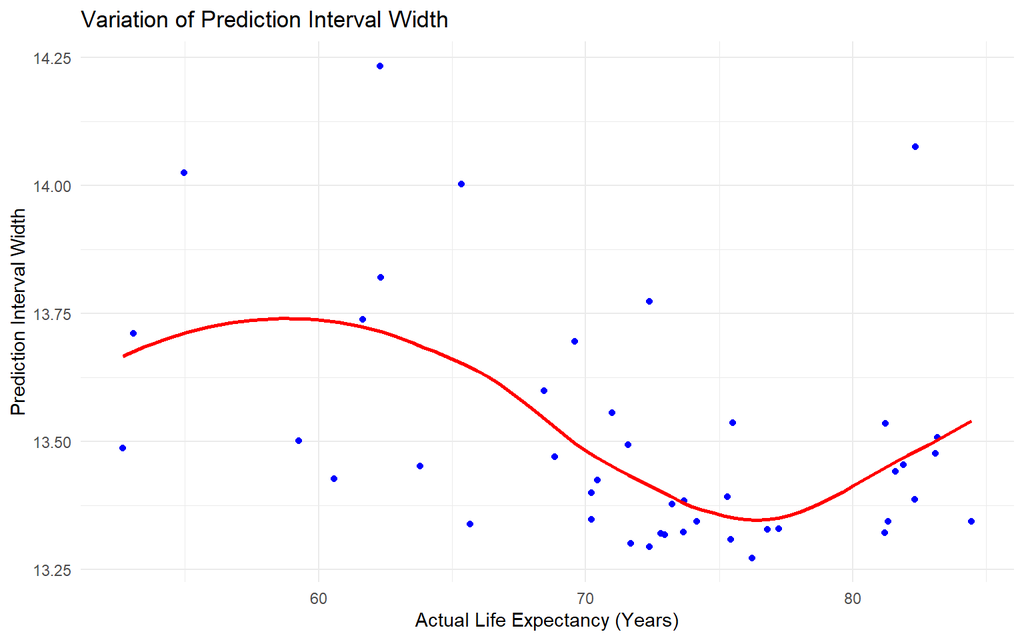

```r
ggplot(results, aes(x = actual, y = Prediction_Interval_Width)) +
  geom_point(color = "blue") +
  geom_smooth(method = "loess", color = "red", se = FALSE) +
  theme_minimal() +
  labs(title = "Variation of Prediction Interval Width",
       x = "Actual Life Expectancy (Years)",
       y = "Prediction Interval Width")
```

The second plot shows the variation of prediction interval widths across the range of actual life expectancy values. The red smoothed line indicates slight fluctuations:

- There is a **minor widening** of prediction intervals for **lower life expectancy values** (around 60 years) and for some **higher values** (above 80 years). This implies slightly increased uncertainty in these ranges, possibly due to fewer data points or greater variability in these parts of the dataset.
- In the middle range of life expectancy (70–80 years), the prediction intervals are **narrower**, indicating greater confidence in the model’s predictions within this range.

```r
outside_interval_count <- sum(countries_test2$Real < countries_test2$Lower | countries_test2$Real > countries_test2$Upper)
total_points <- nrow(countries_test2)
coverage <- round(100 - (outside_interval_count / total_points) * 100, digits = 1)
print(paste("Percentage of points inside the intervals:", coverage, "%"))
```

[output not shown]

Lastly, although the model demonstrates good overall performance, as evidenced by its high adjusted $R^2$ and diagnostic checks, the exploratory analysis highlighted significant **collinearity** among several predictors. To quantify this, **Variance Inflation Factor (VIF)** values were calculated to assess the degree of multicollinearity in the model.

```r
vif_results <- as.data.frame(vif(lr_fit$fit))
```

Variance Inflation Factor (VIF) Results

| Predictor | VIF |
| --- | --- |
| Internet:Drinking_water | 91.177249 |
| Internet | 84.769569 |
| Access_electricity | 3.952284 |
| Fertility_rate | 3.886989 |
| GDP_capita | 2.315388 |
| Unemployment:GDP_capita | 2.263462 |
| Unemployment | 1.295381 |

The results indicate that while most predictors show acceptable multicollinearity (VIF < 10), two predictors exhibit extremely high VIF values:

- `Internet`:84.77
- `Internet:Drinking_water`: 91.18

These high VIF values confirm **substantial multicollinearity** between Internet, its interaction term, and other predictors. Multicollinearity inflates the standard errors of coefficients, reduces the interpretability of the model, and may compromise the stability of the regression results.

Given these findings, **LASSO** (Least Absolute Shrinkage and Selection Operator) regression will be applied to address multicollinearity and enhance model robustness. LASSO is particularly effective in shrinking or eliminating coefficients of less important variables, thereby selecting the most relevant predictors while mitigating the effects of multicollinearity.

### LASSO

**LASSO** (Least Absolute Shrinkage and Selection Operator) is a regression technique that performs variable selection and regularization to enhance the predictive accuracy and interpretability of statistical models. It works by **adding a penalty term** to the ordinary least squares (OLS) loss function, proportional to the absolute values of the regression coefficients.

This penalty causes some **coefficients** to **shrink** towards **zero**, effectively excluding less important predictors from the model. By doing so, LASSO is particularly effective in addressing multicollinearity among predictors and simplifying models.

This R code implements a LASSO regression model, it employs a workflow that includes data preprocessing (normalization of numeric predictors and removal of zero-variance predictors) and hyperparameter tuning for the regularization penalty. Cross-validation is conducted with 10 folds to evaluate the model’s performance across a grid of 20 penalty values using metrics such as RMSE and R-squared. The best penalty value is selected based on the lowest RMSE, and the final model is trained using this optimal configuration.

```r
lasso_spec <- linear_reg(penalty = tune(), mixture = 1) %>%
  set_engine("glmnet") %>%
  set_mode("regression")

recipe <- recipe(Life_expectancy ~ ., data = countries_train2) %>%
  step_normalize(all_numeric_predictors()) %>%
  step_zv(all_predictors())

workflow_lasso <- workflow() %>%
  add_model(lasso_spec) %>%
  add_recipe(recipe)

set.seed(100452928)
cv_folds <- vfold_cv(countries_train2, v = 10)
metrics <- yardstick::metric_set(yardstick::rmse, yardstick::rsq)

lasso_results <- tune_grid(
  workflow_lasso,
  resamples = cv_folds,
  grid = 20,
  metrics = metrics
)
best_lasso <- select_best(lasso_results, "rmse")
final_lasso <- finalize_workflow(workflow_lasso, best_lasso)

lasso_fit <- fit(final_lasso, data = countries_train2)
```

Coefficients Selected by LASSO (with Penalty Value)

| Term | Estimate | Penalty |
| --- | --- | --- |
| (Intercept) | 71.7501951 | 0.1471038 |
| Infant_mortality | -3.7170337 | 0.1471038 |
| GDP_capita | 2.0046682 | 0.1471038 |
| Fertility_rate | -1.0471180 | 0.1471038 |
| Urban_Population | 0.1318575 | 0.1471038 |
| Density | 0.5322452 | 0.1471038 |
| Drinking_water | 0.3439257 | 0.1471038 |
| Access_electricity | 0.4545302 | 0.1471038 |
| Unemployment | -0.3169923 | 0.1471038 |

Performance Metrics for LASSO Model

| Metric | Value |
| --- | --- |
| R² Train | 0.8517 |
| R² Test | 0.8793 |
| MAE | 2.2504 |
| RMSE | 2.8576 |

A noteworthy observation is that the $R^2_{test}$ is slightly higher than the $R^2_{train}$. While this is unusual, it does **not indicate overfitting**. Overfitting would typically manifest as significantly better performance on the training set compared to the test set, which is not the case here. Possible reasons for this observation include:

- **Random Variability:** The test set might coincidentally align better with the patterns captured by the model, resulting in a higher $R^2_{test}$
- **Differences in Variance:** The test set may have lower variability in the target variable, making it easier for the model to achieve a higher $R^2_{test}$

Variance Inflation Factor (VIF) for LASSO-Selected Predictors

| Predictor | VIF |
| --- | --- |
| Infant_mortality | 4.693144 |
| GDP_capita | 1.452390 |
| Fertility_rate | 4.974778 |
| Urban_Population | 1.651345 |
| Density | 1.070768 |
| Drinking_water | 6.407288 |
| Access_electricity | 4.716664 |
| Unemployment | 1.121844 |

This reduction in multicollinearity has likely contributed to the improved predictive performance of the model. By addressing redundancy among predictors and retaining only the most relevant ones, the LASSO regularization ensures that the model is both stable and interpretable. Consequently, the predictions are more reliable, as evidenced by the increased $R^2$ and reduced error metrics compared to the standard linear regression model.

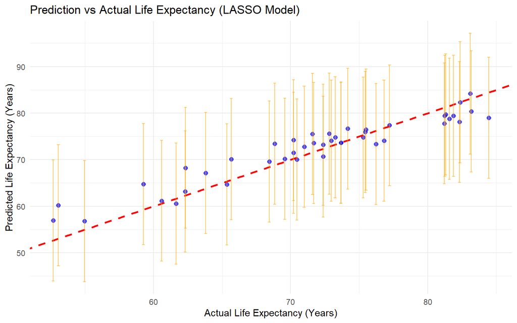

### Best feature selection

The final approach to be tested in this analysis is **best feature selection.** This method involves identifying and selecting the most relevant predictors based on their contribution to the model’s performance. By systematically evaluating subsets of predictors, the goal is to achieve a balance between model complexity and predictive accuracy.

The model begins by fitting a full multiple linear regression to predict `Life_expectancy` based on all available predictors in the training dataset. It then applies a stepwise selection process using the stepAIC function to refine the model. This method iteratively adds or removes predictors based on the Akaike Information Criterion (AIC), aiming to balance model fit and complexity. By choosing the combination of predictors that minimizes AIC, the stepwise approach ensures a more parsimonious model while avoiding overfitting. The resulting model retains only the most relevant variables for predicting `Life_expectancy`.

```r
full_model <- lm(
  Life_expectancy ~ .,
  data = countries_train2
)

stepwise_model <- stepAIC(full_model, direction = "both", trace = F)

summ(stepwise_model, digits = 3)
```

| Observations | 166 |
| --- | --- |
| Dependent variable | Life_expectancy |
| Type | OLS linear regression |

| F(6,159) | 142.183 |
| --- | --- |
| R² | 0.843 |
| Adj. R² | 0.837 |

|  | Est. | S.E. | t val. | p |
| --- | --- | --- | --- | --- |
| (Intercept) | 74.542 | 2.255 | 33.063 | 0.000 |
| Infant_mortality | -0.218 | 0.028 | -7.805 | 0.000 |
| GDP_capita | 0.000 | 0.000 | 7.541 | 0.000 |
| Fertility_rate | -0.872 | 0.396 | -2.203 | 0.029 |
| Density | 0.000 | 0.000 | 2.761 | 0.006 |
| Access_electricity | 0.032 | 0.018 | 1.812 | 0.072 |
| Unemployment | -0.077 | 0.044 | -1.745 | 0.083 |

Standard errors: OLS

$$Life\ expectancy = B_0 + B_1*Infant\ mortality + B_2*GDP\ capita\\+
B_3*Fertility\ Rate +B_4 * Density \\ +B_5 * Access\ electricity+ B_6 *
Unemployment$$

The best model with this method includes the following variables:

- **Infant mortality:** -0.22. For each one-unit increase in infant mortality, life expectancy decreases by 0.22 years. This effect is highly statistically significant (p<0.001).
- **GDP per capita:** 0.00. For every one-unit increase in GDP per capita, life expectancy increases slightly but significantly (p<0.001).
- **Fertility rate:** -0.87. For every one-unit increase in fertility rate, life expectancy decreases by 0.87 years, and this effect is statistically significant (p=0.03).
- **Density:** 0.00. A one-unit increase in population density is associated with a slight but statistically significant increase in life expectancy (p=0.01).
- **Access to electricity:** 0.03. A 1% increase in access to electricity corresponds to a 0.03-year increase in life expectancy. This relationship is marginally significant (p=0.07).
- **Unemployment:** -0.08. For every 1% increase in unemployment, life expectancy decreases by 0.08 years, but this relationship is not statistically significant (p=0.08).

Performance Metrics for Stepwise Selection Model

| Metric | Value |
| --- | --- |
| R² Train | 0.8370 |
| R² Test | 0.8680 |
| MAE | 2.2088 |
| RMSE | 2.7717 |

The adjusted $R^2$ for the training dataset is* **0.84**, while for the test dataset it is **0.87**. This close alignment between training and test performance indicates that the model generalizes well to unseen data, demonstrating its reliability. The overall model is statistically significant, as $F(6,159) = 142.18$ and $p < 0.001$ explaining 84% of the variance in life expectancy.

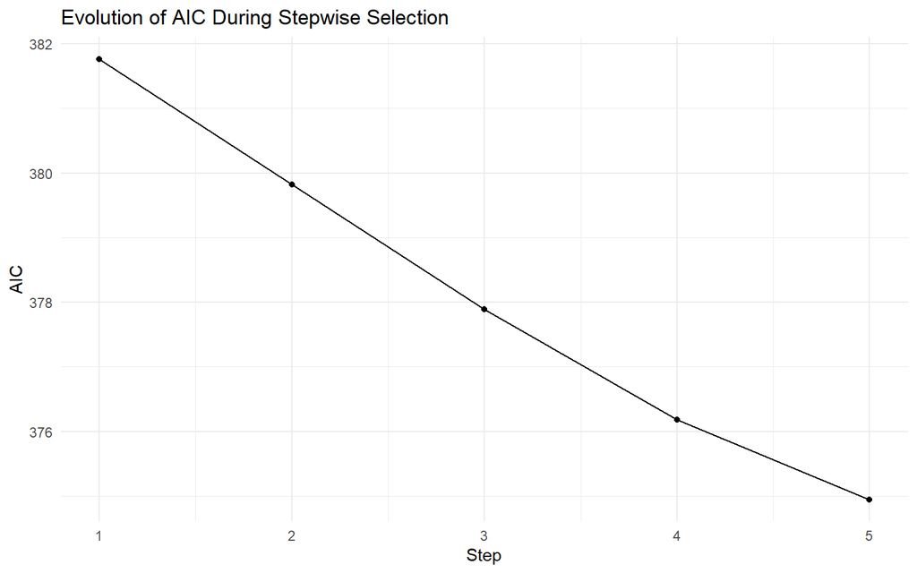

```r
stepwise_trace <- stepAIC(full_model, direction = "both", trace = F)

aic_values <- data.frame(
  Step = seq_along(stepwise_trace$anova$AIC),
  AIC = stepwise_trace$anova$AIC
)

ggplot(aic_values, aes(x = Step, y = AIC)) +
  geom_line() +
  geom_point() +
  labs(
    title = "Evolution of AIC During Stepwise Selection",
    x = "Step",
    y = "AIC"
  ) +
  theme_minimal()
```

The graph illustrates the **evolution** of the **Akaike Information Criterion (AIC)** throughout the stepwise selection process. Each step represents a modification to the model—either adding or removing a predictor—to optimize model fit while minimizing complexity. The AIC decreases steadily across the steps, indicating that the model improves iteratively, ultimately selecting the configuration with the lowest AIC as the optimal balance between goodness of fit and simplicity.

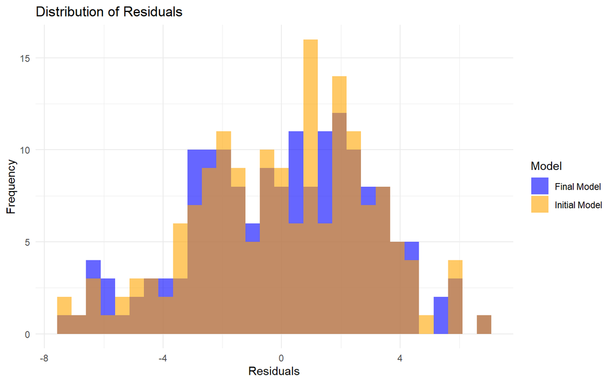

```r
residuals_full <- residuals(full_model)
residuals_final <- residuals(stepwise_model)

residuals_data <- data.frame(
  Residuals = c(residuals_full, residuals_final),
  Model = rep(c("Initial Model", "Final Model"), each = length(residuals_full))
)

ggplot(residuals_data, aes(x = Residuals, fill = Model)) +
  geom_histogram(alpha = 0.6, bins = 30, position = "identity") +
  labs(
    title = "Distribution of Residuals",
    x = "Residuals",
    y = "Frequency"
  ) +
  theme_minimal() +
  scale_fill_manual(values = c("blue", "orange"))
```

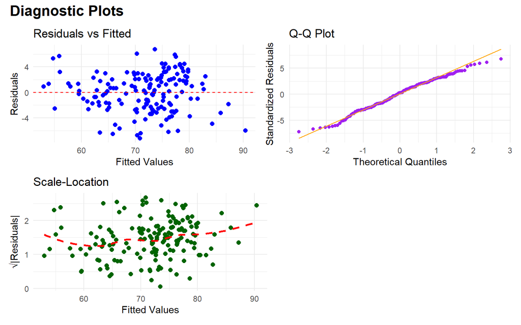

The Residuals vs Fitted plot shows residuals evenly scattered around zero, indicating no major violations of linearity. The Q-Q Plot suggests that the residuals approximately follow a normal distribution, as most points align with the diagonal line. The Scale-Location plot shows residuals with fairly constant variance across fitted values, supporting the assumption of homoscedasticity. Overall, the diagnostic plots indicate that the model performs well and meets the key assumptions of linear regression.

```r
residuals <- residuals(stepwise_model)

ks_test <- ks.test(residuals, "pnorm", mean(residuals), sd(residuals))


bp_test <- bptest(stepwise_model)

test_results <- data.frame(
  Test = c("Kolmogorov-Smirnov Test", "Breusch-Pagan Test"),
  `p-value` = c(ks_test$p.value, bp_test$p.value),
  Conclusion = c(
    ifelse(ks_test$p.value > 0.05,
           "Residuals likely follow a normal distribution.",
           "Residuals do not follow a normal distribution."),
    ifelse(bp_test$p.value > 0.05,
           "Residuals have constant variance (homoscedasticity).",
           "Residuals do not have constant variance (heteroscedasticity).")
  )
)

kable(test_results, caption = "Diagnostic Test Results", align = "c", rownames = FALSE) %>%
  kable_styling(bootstrap_options = c("striped", "hover", "condensed"), full_width = FALSE)
```

Diagnostic Test Results

|  | Test | p.value | Conclusion |
| --- | --- | --- | --- |
|  | Kolmogorov-Smirnov Test | 0.6523015 | Residuals likely follow a normal distribution. |
| BP | Breusch-Pagan Test | 0.0572247 | Residuals have constant variance (homoscedasticity). |

The table summarizes the results of two diagnostic tests for the regression model. The Kolmogorov-Smirnov Test yields a p-value of 0.65, indicating that the residuals likely follow a normal distribution, satisfying the assumption of normality. The Breusch-Pagan Test gives a p-value of 0.057, suggesting that the residuals have constant variance (homoscedasticity), as the result is marginally above the typical significance threshold of 0.05. Together, these results support the validity of the model’s assumptions.

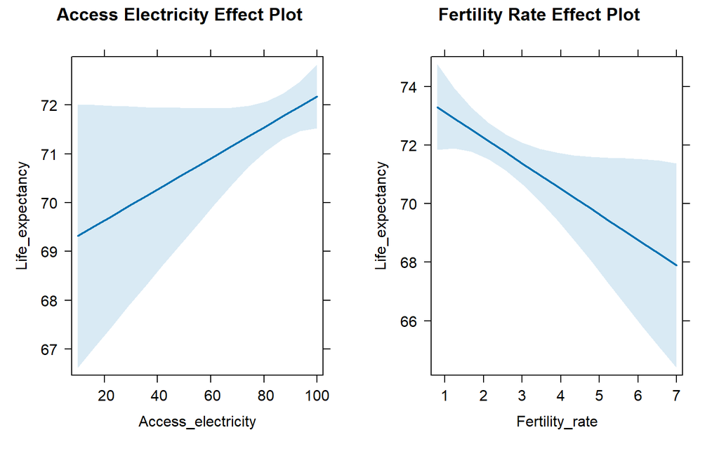

```r
efects <- allEffects(stepwise_model)

p1 <- plot(efects[["Access_electricity"]], rug = FALSE, main = "Access Electricity Effect Plot", cex.main = 1.5)
p2 <- plot(efects[["Fertility_rate"]], rug = FALSE, main = "Fertility Rate Effect Plot", cex.main = 1.5)

grid.arrange(p1, p2, ncol = 2)
```

The plots show the effects of `Access_electricity` and `Fertility_rate` on predicted life expectancy. As access to electricity increases, life expectancy shows a positive linear trend, indicating that higher access to electricity is associated with longer life expectancy. The confidence interval (shaded region) narrows for higher electricity access, indicating more consistent predictions in those ranges, likely due to more data points or reduced variability. Conversely, as the fertility rate increases, life expectancy decreases, suggesting a negative relationship. For fertility rate, the confidence interval widens at higher values, reflecting greater uncertainty in predictions for higher fertility rates, possibly due to fewer data points in that range. Both effects align with expected socioeconomic patterns influencing life expectancy.

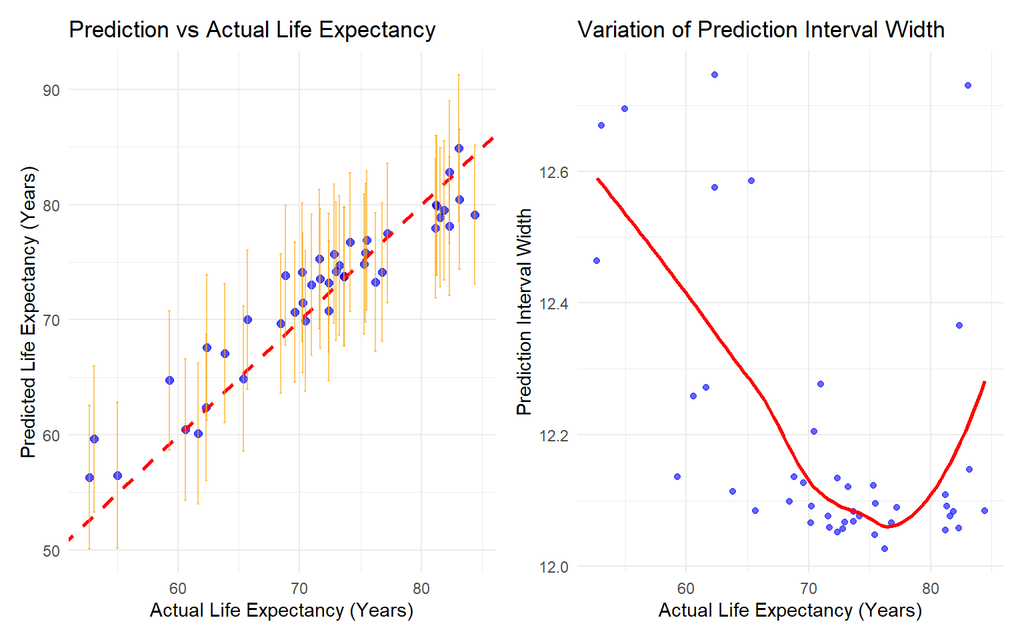

```r
predict_with_intervals <- predict(stepwise_model, newdata = countries_test2, interval = "prediction")

resultados <- as_tibble(predict_with_intervals) %>%
  bind_cols(
    actual = countries_test2$Life_expectancy,
    Internet = countries_test2$Internet
  ) %>%
  mutate(Prediction_Interval_Width = upr - lwr)

p1 <- ggplot(resultados, aes(x = actual, y = fit)) +
  geom_point(color = "blue", alpha = 0.7, size = 2) +
  geom_abline(slope = 1, intercept = 0, color = "red", linetype = "dashed", size = 1) +
  geom_errorbar(aes(ymin = lwr, ymax = upr), width = 0.2, color = "orange", alpha = 0.6) +
  labs(
    title = "Prediction vs Actual Life Expectancy",
    x = "Actual Life Expectancy (Years)",
    y = "Predicted Life Expectancy (Years)"
  ) +
  theme_minimal()

p2 <- ggplot(resultados, aes(x = actual, y = Prediction_Interval_Width)) +
  geom_point(color = "blue", alpha = 0.6) +
  geom_smooth(method = "loess", color = "red", se = FALSE) +
  theme_minimal() +
  labs(
    title = "Variation of Prediction Interval Width",
    x = "Actual Life Expectancy (Years)",
    y = "Prediction Interval Width"
  )

p1 + p2
```

```r
interval_summary <- data.frame(
  Statistic = c("Min", "1st Quartile", "Median", "Mean", "3rd Quartile", "Max"),
  Value = as.numeric(summary(resultados$Prediction_Interval_Width))
)

interval_summary %>%
  kable(
    caption = "Summary of Prediction Interval Widths",
    align = "c"
  ) %>%
  kable_styling(bootstrap_options = c("striped", "hover", "condensed"), full_width = FALSE)
```

Summary of Prediction Interval Widths

| Statistic | Value |
| --- | --- |
| Min | 12.02634 |
| 1st Quartile | 12.07396 |
| Median | 12.09685 |
| Mean | 12.19646 |
| 3rd Quartile | 12.21826 |
| Max | 12.74666 |

The predictions (blue points) closely follow the diagonal line (ideal prediction), indicating good model performance. The orange error bars represent prediction intervals, which remain fairly consistent across the range of actual values, with slight widening at the extremes.

The second plot illustrates the variation in prediction interval width against actual life expectancy. The interval width (blue points) remains relatively narrow and consistent overall, with a slight U-shaped trend where the intervals are narrower for mid-range life expectancy values and slightly wider at the extremes, suggesting more uncertainty in these areas.

The summary table provides descriptive statistics of the prediction interval widths, which range between 12.02 and 12.75, with a mean width of approximately 12.2. This narrow range indicates that the prediction intervals are stable and do not vary significantly, reflecting consistency in the model’s predictive confidence.

```r
outside_interval_count <- sum(resultados$actual < resultados$lwr | resultados$actual > resultados$upr)

total_points <- nrow(resultados)

coverage <- round(100 - (outside_interval_count / total_points) * 100, digits = 1)

print(paste("Percentage of points inside the intervals:", coverage, "%"))
```

```
## [1] "Percentage of points inside the intervals: 97.7 %"
```

The percentage of points inside the intervals is now 97.7%, which is significantly higher compared to the model with interactions. This indicates that the current model provides a much better fit for capturing the range of actual values within the prediction intervals.

```r
vif_results <- as.data.frame(vif(stepwise_model))
```

Variance Inflation Factor (VIF) Results

| Predictor | VIF |
| --- | --- |
| Fertility_rate | 4.630401 |
| Infant_mortality | 4.380885 |
| Access_electricity | 3.227532 |
| GDP_capita | 1.393302 |
| Unemployment | 1.104686 |
| Density | 1.040614 |

The Variance Inflation Factor (VIF) analysis results demonstrate that the model created using the best predictor selection approach does not exhibit multicollinearity issues. All predictors have VIF values below the threshold of 5, indicating low correlation among the independent variables and ensuring the reliability of the regression estimates.

### Benchmark Model

A benchmark model is a simple, baseline model used to compare against a more complex model to evaluate its performance. It provides a reference point to determine if the more advanced model adds value. For this case, we chose a benchmark that predicts the mean of the dependent variable. This approach is commonly used because it is straightforward, easy to implement, and provides a clear baseline to evaluate whether the stepwise regression model significantly improves prediction accuracy over simply predicting the average.

```r
mean_life_expectancy <- mean(countries_train2$Life_expectancy)

benchmark_pred <- rep(mean(real), n)
```

Comparison of Stepwise Model and Benchmark Model

| Metric | Benchmark Model |
| --- | --- |
| R² Test | 0.0000 |
| MAE | 6.4450 |
| RMSE | 8.2246 |

The table compares the performance metrics of the benchmark model. The $R^2$ value is 0.0000, which is expected for a benchmark model based on predicting the mean of the dependent variable. This occurs because the benchmark model does not explain any variability beyond the mean, resulting in $SSE = SST$. The Mean Absolute Error (MAE) and Root Mean Square Error (RMSE) values indicate the average prediction errors, which are expected to be relatively high given the simplicity of the benchmark model. This baseline is useful to demonstrate whether the stepwise regression model significantly improves prediction performance.

## Comparision between models and conclusions

Once all the models have been created and evaluated we can compared them to choose the best one.

Summary of Performance Metrics for All Models

| Metric | Benchmark Model | Interactions Model | LASSO Model | Stepwise Model |
| --- | --- | --- | --- | --- |
| R² Train | NA | 0.8015 | 0.8517 | 0.8370 |
| R² Test | 0.0000 | 0.7954 | 0.8793 | 0.8680 |
| MAE | 6.4450 | 2.8298 | 2.2504 | 2.2088 |
| RMSE | 8.2246 | 3.7628 | 2.8576 | 2.7717 |

The benchmark model, which predicts the mean life expectancy for all countries, serves as a simple baseline for comparison. While it provides a basic reference point, it fails to capture any of the underlying relationships between life expectancy and other variables.

An initial manually constructed model improved upon the benchmark by incorporating relevant predictors. However, this model exhibited significant **multicollinearity** which can inflate variance and lead to unreliable coefficient estimates. Multicollinearity makes it difficult to discern the individual effect of each predictor, undermining the model’s interpretability and stability.

To mitigate multicollinearity and enhance predictive performance, we applied **LASSO** (Least Absolute Shrinkage and Selection Operator) regression. This approach improved the model’s predictive accuracy compared to the manual model. However, the **interpretability** of the LASSO model **decreased** because the regularization process can obscure the impact of individual predictors, especially when coefficients are shrunk or eliminated entirely.

Finally, we employed **stepwise feature selection** to build a model that maintains strong predictive power while enhancing interpretability. The resulting model not only achieved better predictive performance than the manual model and was comparable to the LASSO model but also was simpler and easier to interpret by including only the most significant variables and excluding redundant ones.

# GLM

In the highly competitive telecommunications industry, retaining customers and identifying opportunities for cross-selling are critical strategies for ensuring sustainable growth. This project aims to develop a predictive model to identify customers most likely to purchase a product in the upcoming month.

```r
mobile <- read.csv2("D:/1.Universidad/Predictive modeling/data_mobile.csv")
mobile$TARGET = as.factor(mobile$TARGET)
```

The dataset used for this analysis was obtained from a collection provided last year by Professor Álvaro Gonzalo de Alba in the UC3M. The dataset contains the following variables:

- **MB_TOTAL:** Total megabytes consumed by the customer.
- **INVOICING_TOTAL_TAXES:** Total billing amount, including taxes.
- **INVOICING_QUOTA:** Billing for subscription services only.
- **SECONDS_CALL_OWN_NETWORK:** Total seconds spent on calls within the company’s network.
- **SECONDS_OUTGOING_CALL_OWN_NETWORK:** Total seconds spent on outgoing calls within the company’s network.
- **SECONDS_INCOMING_CALL_OWN_NETWORK:** Total seconds spent on incoming calls within the company’s network.
- **MONTHLY_MB:** Average monthly megabytes consumed by the customer.
- **AGE:** Approximate age of the customer (±5 years).
- **NUM_CALLS_OWN_NETWORK:** Number of calls made within the company’s network.
- **INVOICING_TOTAL_WITHOUT_TAXES:** Total billing amount, excluding taxes.
- **NUM_MAIN_POSTPAID_LINES:** Number of main postpaid lines associated with the customer.
- **NUM_POSTPAID_LINES:** Total number of postpaid lines.
- **NUM_FIXED_LINES:** Number of fixed lines associated with the customer.
- **NUM_DAYS_CONVERGENT:** Number of days the customer has had both fixed and mobile services.
- **NUM_FIXED_POSTPAID_LINES:** Number of fixed postpaid lines.
- **NUM_POSTPAID_SERVICES:** Number of postpaid services utilized by the customer.
- **DAYS_FIRST_ACCOUNT:** Number of days since the customer first opened an account.
- **NUM_CANCELLATIONS:** Total number of canceled services.
- **MOBILE_CALLS:** Number of calls made using mobile services.
- **NUM_TOTAL_POSTPAID_LINES:** Total number of all postpaid lines associated with the customer.
- **INVOICING_TERM:** Term details of the customer’s billing agreement.
- **NUM_FIXED_POSTPAID_DEACTIVATIONS:** Number of deactivations of fixed postpaid services.
- **NUM_FIXED_DEACTIVATIONS:** Number of deactivations of fixed services overall.
- **NUM_LINES_UNKNOWN_TECHNOLOGY:** Number of lines using unknown technology.
- **NUM_DAYS_ACTIVE:** Total number of days the customer has been active.
- **MONTHLY_CALL_MINUTES:** Total minutes spent on calls each month.
- **NUM_BUNDLE_DAYS:** Number of days with issues related to bundled services.
- **KPI_TAXES:** Taxes applied to the customer’s main invoice.
- **NUM_DEACTIVATIONS:** Total number of service deactivations across all lines.
- **PERCENTAGE_SECONDS_OWN_NETWORK:** Percentage of call seconds spent within the company’s network.
- **TOTAL_BRAND_SERVICES:** Total number of services under the company’s brand.
- **TOTAL_POSTPAID_SERVICES:** Total number of postpaid services associated with the customer.
- **MOBILE_CALL_MINUTES:** Total minutes spent on mobile calls.
- **ZONE_FIXED_PENETRATION:** Percentage of people in the customer’s area who use fixed-line services.
- **TARGET:** Binary variable indicating whether the customer purchased a product in the next month (1 for yes, 0 for no).

## Data preparation and exploratory analysis

Data summary

| Name | mobile |
| --- | --- |
| Number of rows | 20000 |
| Number of columns | 35 |
| _______________________ |  |
| Column type frequency: |  |
| factor | 1 |
| numeric | 34 |
| ________________________ |  |
| Group variables | None |

**Variable type: factor**

| skim_variable | n_missing | complete_rate | ordered | n_unique | top_counts |
| --- | --- | --- | --- | --- | --- |
| TARGET | 0 | 1 | FALSE | 2 | 0: 13779, 1: 6221 |

**Variable type: numeric**

| skim_variable | n_missing | complete_rate | mean | sd | p0 | p25 | p50 | p75 | p100 | hist |
| --- | --- | --- | --- | --- | --- | --- | --- | --- | --- | --- |
| MB_TOTAL | 259 | 0.99 | 12307.32 | 20115.50 | 0.00 | 1929.67 | 5931.52 | 16013.45 | 853613.59 | ▇▁▁▁▁ |
| INVOICING_TOTAL_TAXES | 76 | 1.00 | 40.94 | 30.33 | 0.00 | 25.00 | 33.00 | 50.12 | 1246.44 | ▇▁▁▁▁ |
| INVOICING_QUOTA | 76 | 1.00 | 25.18 | 13.07 | 0.00 | 15.70 | 23.97 | 26.46 | 133.89 | ▇▂▁▁▁ |
| SECONDS_CALL_OWN_NETWORK | 157 | 0.99 | 19282.84 | 31773.41 | 0.00 | 1777.00 | 8011.00 | 23009.50 | 584239.00 | ▇▁▁▁▁ |
| SECONDS_OUTGOING_CALL_OWN_NETWORK | 157 | 0.99 | 10334.95 | 18971.93 | 0.00 | 705.50 | 3631.00 | 11846.50 | 422724.00 | ▇▁▁▁▁ |
| SECONDS_INCOMING_CALL_OWN_NETWORK | 157 | 0.99 | 62.94 | 93.53 | 0.00 | 11.00 | 36.00 | 82.00 | 6220.00 | ▇▁▁▁▁ |
| MONTHLY_MB | 251 | 0.99 | 12288.03 | 20112.80 | 0.00 | 1915.53 | 5898.41 | 15967.20 | 853613.59 | ▇▁▁▁▁ |
| AGE | 29 | 1.00 | 43.99 | 14.13 | 17.00 | 33.00 | 43.00 | 54.00 | 98.00 | ▆▇▆▂▁ |
| NUM_CALLS_OWN_NETWORK | 157 | 0.99 | 156.41 | 227.91 | 0.00 | 29.00 | 87.00 | 199.00 | 12497.00 | ▇▁▁▁▁ |
| INVOICING_TOTAL_WITHOUT_TAXES | 76 | 1.00 | 35.28 | 27.64 | 0.00 | 20.66 | 28.03 | 43.44 | 1223.80 | ▇▁▁▁▁ |
| NUM_MAIN_POSTPAID_LINES | 0 | 1.00 | 1.15 | 0.44 | 0.00 | 1.00 | 1.00 | 1.00 | 5.00 | ▇▁▁▁▁ |
| NUM_POSTPAID_LINES | 0 | 1.00 | 1.38 | 0.71 | 1.00 | 1.00 | 1.00 | 2.00 | 8.00 | ▇▁▁▁▁ |
| NUM_FIXED_LINES | 0 | 1.00 | 0.00 | 0.03 | 0.00 | 0.00 | 0.00 | 0.00 | 2.00 | ▇▁▁▁▁ |
| NUM_DAYS_CONVERGENT | 0 | 1.00 | 17.08 | 120.82 | 0.00 | 0.00 | 0.00 | 0.00 | 3387.00 | ▇▁▁▁▁ |
| NUM_FIXED_POSTPAID_LINES | 0 | 1.00 | 0.00 | 0.03 | 0.00 | 0.00 | 0.00 | 0.00 | 2.00 | ▇▁▁▁▁ |
| NUM_POSTPAID_SERVICES | 0 | 1.00 | 1.38 | 0.71 | 1.00 | 1.00 | 1.00 | 2.00 | 8.00 | ▇▁▁▁▁ |
| DAYS_FIRST_ACCOUNT | 0 | 1.00 | 1314.95 | 930.55 | 0.00 | 563.00 | 1138.00 | 1935.00 | 4959.00 | ▇▆▃▁▁ |
| NUM_CANCELLATIONS | 0 | 1.00 | 0.70 | 1.19 | 0.00 | 0.00 | 0.00 | 1.00 | 22.00 | ▇▁▁▁▁ |
| MOBILE_CALLS | 82 | 1.00 | 0.28 | 7.82 | 0.00 | 0.00 | 0.00 | 0.00 | 412.00 | ▇▁▁▁▁ |
| NUM_TOTAL_POSTPAID_LINES | 0 | 1.00 | 1.80 | 1.35 | 0.00 | 1.00 | 1.00 | 2.00 | 19.00 | ▇▁▁▁▁ |
| INVOICING_TERM | 76 | 1.00 | 6.97 | 17.79 | 0.00 | 0.00 | 0.00 | 8.00 | 1116.00 | ▇▁▁▁▁ |
| NUM_FIXED_POSTPAID_DEACTIVATIONS | 0 | 1.00 | 0.00 | 0.05 | 0.00 | 0.00 | 0.00 | 0.00 | 1.00 | ▇▁▁▁▁ |
| NUM_FIXED_DEACTIVATIONS | 0 | 1.00 | 0.00 | 0.05 | 0.00 | 0.00 | 0.00 | 0.00 | 1.00 | ▇▁▁▁▁ |
| NUM_LINES_UNKNOWN_TECHNOLOGY | 0 | 1.00 | 1.38 | 0.71 | 1.00 | 1.00 | 1.00 | 2.00 | 8.00 | ▇▁▁▁▁ |
| NUM_DAYS_ACTIVE | 550 | 0.97 | 1259.56 | 940.45 | 0.00 | 495.00 | 1051.00 | 1870.00 | 4959.00 | ▇▅▃▁▁ |
| MONTHLY_CALL_MINUTES | 251 | 0.99 | 361.82 | 543.39 | 0.00 | 65.00 | 178.97 | 443.58 | 12316.25 | ▇▁▁▁▁ |
| NUM_BUNDLE_DAYS | 0 | 1.00 | 148.79 | 476.20 | 0.00 | 0.00 | 1.00 | 2.00 | 4056.00 | ▇▁▁▁▁ |
| KPI_TAXES | 76 | 1.00 | 5.66 | 3.55 | -1.19 | 3.30 | 5.03 | 6.77 | 93.48 | ▇▁▁▁▁ |
| NUM_DEACTIVATIONS | 0 | 1.00 | 0.01 | 0.10 | 0.00 | 0.00 | 0.00 | 0.00 | 4.00 | ▇▁▁▁▁ |
| PERCENTAGE_SECONDS_OWN_NETWORK | 263 | 0.99 | 99.98 | 1.28 | 0.00 | 100.00 | 100.00 | 100.00 | 100.00 | ▁▁▁▁▇ |
| TOTAL_BRAND_SERVICES | 0 | 1.00 | 1.43 | 0.76 | 1.00 | 1.00 | 1.00 | 2.00 | 8.00 | ▇▁▁▁▁ |
| TOTAL_POSTPAID_SERVICES | 0 | 1.00 | 1.79 | 1.33 | 0.00 | 1.00 | 1.00 | 2.00 | 18.00 | ▇▁▁▁▁ |
| MOBILE_CALL_MINUTES | 82 | 1.00 | 0.91 | 30.43 | 0.00 | 0.00 | 0.00 | 0.00 | 2089.32 | ▇▁▁▁▁ |
| ZONE_FIXED_PENETRATION | 1323 | 0.93 | 0.26 | 0.07 | 0.04 | 0.20 | 0.26 | 0.30 | 0.38 | ▁▃▇▇▆ |

The dataset is divided into a training set and a test set, with 75% of the data assigned to training and the remaining 25% set aside for testing. This split was selected to maximize the number of observations available for model training while retaining enough data for evaluation. The training set will be utilized for exploratory data analysis, feature selection, and model development. Meanwhile, the test set will be used solely to assess the predictive performance of the final models, ensuring an impartial evaluation of their accuracy and effectiveness.

Before splitting the dataset into training and test sets, it is crucial to examine the distribution of the response variable (`TARGET`). This ensures that the classes are balanced and helps determine if stratified sampling is necessary during the split.

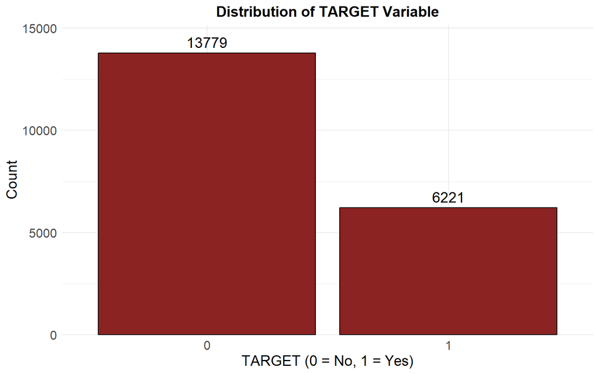

```r
ggplot(mobile, aes(x = factor(TARGET))) +
  geom_bar(fill = "brown4", color = "black") +
  geom_text(stat = "count", aes(label = ..count..), vjust = -0.5, size = 5) +
  labs(
    title = "Distribution of TARGET Variable",
    x = "TARGET (0 = No, 1 = Yes)",
    y = "Count"
  ) +
  theme_minimal() +
  theme(
    plot.title = element_text(size = 14, face = "bold", hjust = 0.5),
    axis.text = element_text(size = 12),
    axis.title = element_text(size = 14)
  ) +
  scale_y_continuous(expand = expansion(mult = c(0, 0.1)))
```

As observed in the distribution of the `TARGET` variable, the dataset is imbalanced, with a significantly higher number of instances in one class compared to the other. To address this, we use the strata argument during the dataset split to ensure that the training and test sets maintain the same class proportions as the original dataset.

```r
set.seed(100452928)
data_split <- initial_split(mobile, prop = 0.75, strata = TARGET)
mobile_train <- training(data_split)
mobile_test <- testing(data_split)
```

After the partition the training set contains 14999 instances while the testing set contains 5001 instances.

### Target variable

As previously observed, the `TARGET` variable is imbalanced, with a higher proportion of 0s compared to 1s. This imbalance is also reflected in the training set, as stratified sampling was applied during the split to ensure that the class proportions remain consistent with those of the original dataset.

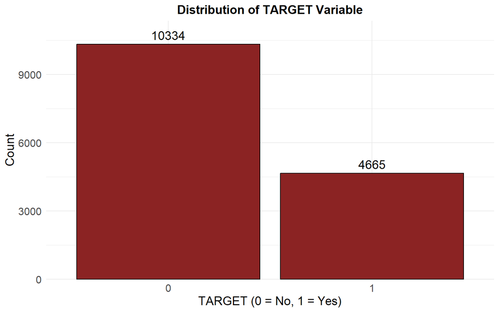

```r
ggplot(mobile_train, aes(x = factor(TARGET))) +
  geom_bar(fill = "brown4", color = "black") +
  geom_text(stat = "count", aes(label = ..count..), vjust = -0.5, size = 5) +
  labs(
    title = "Distribution of TARGET Variable",
    x = "TARGET (0 = No, 1 = Yes)",
    y = "Count"
  ) +
  theme_minimal() +
  theme(
    plot.title = element_text(size = 14, face = "bold", hjust = 0.5),
    axis.text = element_text(size = 12),
    axis.title = element_text(size = 14)
  ) +
  scale_y_continuous(expand = expansion(mult = c(0, 0.1)))
```

To evaluate the correlation between the predictor variables and the target variable, a *t-test* was used because all the predictor variables are *numeric.* The t-test is a statistical method that assesses whether there are significant differences in the means of a numeric variable between two groups. In this context, the two groups are defined by the `TARGET` variable.

The t-test evaluates the null hypothesis that the means of the numeric variable are equal across the two `TARGET` categories. A low p-value from the t-test indicates that the differences in means are statistically significant, suggesting that the variable might be relevant for predicting the target variable.

The table displays the variables with p-values greater than 0.05, indicating that they do not have a statistically significant relationship with the target variable. As these variables lack meaningful predictive power, they will be excluded during the preprocessing phase to streamline the model and improve its performance.

```r
p_values %>%
  mutate(P_Value = round(as.numeric(P_Value), 3)) %>%
  filter(P_Value > 0.05) %>%
  arrange(desc(P_Value)) %>%
  kable(
    caption = "P-Values > 0.05 for Predictor Variables",
    col.names = c("Variable", "P-Value"),
    format = "html"
  ) %>%
  kable_styling(bootstrap_options = c("striped", "hover", "condensed"), full_width = FALSE)
```

P-Values > 0.05 for Predictor Variables

| Variable | P-Value |
| --- | --- |
| NUM_FIXED_POSTPAID_DEACTIVATIONS | 0.350 |
| NUM_FIXED_DEACTIVATIONS | 0.350 |
| NUM_DEACTIVATIONS | 0.216 |
| PERCENTAGE_SECONDS_OWN_NETWORK | 0.121 |

### Predictor variables

#### Missing Values

The next step involves examining the **missing values** in the dataset.

```r
missing_values <- mobile_train %>%
  dplyr::summarise(across(everything(), ~ sum(is.na(.)))) %>%
  pivot_longer(cols = everything(), names_to = "Variable", values_to = "Missing_Count")
```

Summary of Missing Values in the Dataset

| Variable | Missing Count |
| --- | --- |
| ZONE_FIXED_PENETRATION | 1006 |
| NUM_DAYS_ACTIVE | 414 |
| PERCENTAGE_SECONDS_OWN_NETWORK | 205 |
| MB_TOTAL | 196 |
| MONTHLY_MB | 190 |
| MONTHLY_CALL_MINUTES | 190 |
| SECONDS_CALL_OWN_NETWORK | 129 |
| SECONDS_OUTGOING_CALL_OWN_NETWORK | 129 |
| SECONDS_INCOMING_CALL_OWN_NETWORK | 129 |
| NUM_CALLS_OWN_NETWORK | 129 |
| MOBILE_CALLS | 65 |
| MOBILE_CALL_MINUTES | 65 |
| INVOICING_TOTAL_TAXES | 60 |
| INVOICING_QUOTA | 60 |
| INVOICING_TOTAL_WITHOUT_TAXES | 60 |
| INVOICING_TERM | 60 |
| KPI_TAXES | 60 |
| AGE | 25 |

There are several variables with **missing values** in the dataset, as shown in the table. To address this, boxplots are generated for each variable with missing data to visualize their distributions. These visualizations help determine the most appropriate imputation strategy, such as using the median, mean, or other methods, to fill in the missing values while preserving the characteristics of the data.

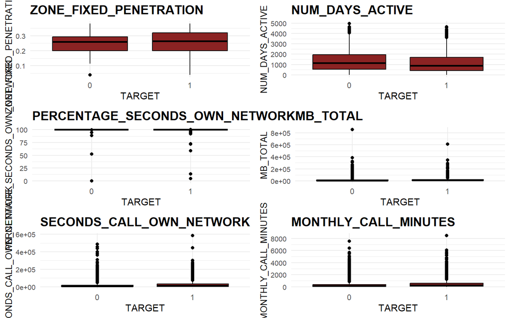

```r
selected_vars <- c("ZONE_FIXED_PENETRATION", "NUM_DAYS_ACTIVE", "PERCENTAGE_SECONDS_OWN_NETWORK",
                   "MB_TOTAL", "SECONDS_CALL_OWN_NETWORK", "MONTHLY_CALL_MINUTES")


plots <- list()

for (var in selected_vars) {
  p <- ggplot(mobile_train, aes(x = as.factor(TARGET), y = .data[[var]])) +
    geom_boxplot(fill = "brown4", color = "black") +
    labs(
      title = var,
      x = "TARGET",
      y = var
    ) +
    theme_minimal() +
    theme(
      axis.title.y = element_text(size = 10),
      axis.text.y = element_text(size = 8),
      plot.title = element_text(size = 14, face = "bold")
    )

  plots[[var]] <- p
}

do.call(grid.arrange, c(plots, ncol = 2))
```

As observed, there is a significant number of outliers present in the variables with missing data. Given this, the **median** is the most optimal imputation method as it is less sensitive to extreme values compared to the mean. This approach ensures that the imputed values align with the central tendency of the data while minimizing the impact of outliers on the overall analysis.

#### Correlation

The next step involves examining the correlation among the predictive variables. This analysis helps identify potential multicollinearity.

```r
countries_numeric <- mobile_train %>%
  dplyr::select(where(is.numeric))

cor_matrix <- cor(countries_numeric, use = "complete.obs")

umbral_correlacion <- 0.75

cor_high <- which(abs(cor_matrix) >= umbral_correlacion, arr.ind = TRUE)

cor_high <- cor_high[cor_high[, 1] > cor_high[, 2], ]

correlation_melt <- melt(cor_matrix)

correlation_melt_upper <- correlation_melt %>%
  filter(as.numeric(Var1) <= as.numeric(Var2))
```

Highly Correlated Predictor Variables

| Variable 1 | Variable 2 | Correlation Value |
| --- | --- | --- |
| NUM_POSTPAID_SERVICES | NUM_POSTPAID_LINES | 1.0000000 |
| NUM_LINES_UNKNOWN_TECHNOLOGY | NUM_POSTPAID_LINES | 1.0000000 |
| NUM_FIXED_POSTPAID_LINES | NUM_FIXED_LINES | 1.0000000 |
| NUM_LINES_UNKNOWN_TECHNOLOGY | NUM_POSTPAID_SERVICES | 1.0000000 |
| NUM_FIXED_DEACTIVATIONS | NUM_FIXED_POSTPAID_DEACTIVATIONS | 1.0000000 |
| MONTHLY_MB | MB_TOTAL | 0.9996809 |
| TOTAL_POSTPAID_SERVICES | NUM_TOTAL_POSTPAID_LINES | 0.9971456 |
| INVOICING_TOTAL_WITHOUT_TAXES | INVOICING_TOTAL_TAXES | 0.9969119 |
| NUM_CALLS_OWN_NETWORK | SECONDS_INCOMING_CALL_OWN_NETWORK | 0.9640605 |
| TOTAL_BRAND_SERVICES | NUM_POSTPAID_LINES | 0.9459464 |
| TOTAL_BRAND_SERVICES | NUM_POSTPAID_SERVICES | 0.9459464 |
| TOTAL_BRAND_SERVICES | NUM_LINES_UNKNOWN_TECHNOLOGY | 0.9459464 |
| SECONDS_OUTGOING_CALL_OWN_NETWORK | SECONDS_CALL_OWN_NETWORK | 0.9378152 |
| NUM_DAYS_ACTIVE | DAYS_FIRST_ACCOUNT | 0.8922128 |
| MOBILE_CALL_MINUTES | MOBILE_CALLS | 0.8135215 |
| KPI_TAXES | INVOICING_TOTAL_TAXES | 0.8088451 |
| INVOICING_TERM | INVOICING_TOTAL_WITHOUT_TAXES | 0.7934752 |
| NUM_POSTPAID_LINES | INVOICING_QUOTA | 0.7808233 |
| NUM_POSTPAID_SERVICES | INVOICING_QUOTA | 0.7808233 |
| NUM_LINES_UNKNOWN_TECHNOLOGY | INVOICING_QUOTA | 0.7808233 |
| KPI_TAXES | INVOICING_TOTAL_WITHOUT_TAXES | 0.7601710 |
| MONTHLY_CALL_MINUTES | SECONDS_OUTGOING_CALL_OWN_NETWORK | 0.7573435 |
| INVOICING_TERM | INVOICING_TOTAL_TAXES | 0.7523086 |

Based on the analysis of correlations, the following decisions were made to select the most representative variables while removing redundant ones:

##### Variables with Perfect Correlation (1)

- Between `NUM_POSTPAID_SERVICES` and `NUM_POSTPAID_LINES`, we chose to keep `NUM_POSTPAID_SERVICES` as it better summarizes postpaid services.
- Between `NUM_LINES_UNKNOWN_TECHNOLOGY` and `NUM_POSTPAID_LINES`,`we retained`NUM_POSTPAID_SERVICES`.
- For `NUM_FIXED_POSTPAID_LINES` and `NUM_FIXED_LINES`, we decided to keep `NUM_FIXED_LINES` because it is a more general variable.
- Between `NUM_FIXED_DEACTIVATIONS` and `NUM_FIXED_POSTPAID_DEACTIVATIONS`, we retained `NUM_FIXED_DEACTIVATIONS`, which includes all deactivations.

##### Variables with Very High Correlation (>0.95)

- Between `MONTHLY_MB` and `MB_TOTAL`, we chose to keep `MONTHLY_MB` as it represents average monthly usage.
- For `TOTAL_POSTPAID_SERVICES` and `NUM_TOTAL_POSTPAID_LINES`, we retained `TOTAL_POSTPAID_SERVICES`, which includes all services.
- Between `INVOICING_TOTAL_WITHOUT_TAXES` and `INVOICING_TOTAL_TAXES`, we kept `INVOICING_TOTAL_TAXES` as it includes taxes and provides a more complete financial perspective.
- For `NUM_CALLS_OWN_NETWORK` and `SECONDS_INCOMING_CALL_OWN_NETWORK`, we decided to retain `NUM_CALLS_OWN_NETWORK` since a count is easier to interpret than call duration in seconds.

##### Variables with High Correlation (>0.75)

- Between `TOTAL_BRAND_SERVICES` and variables `NUM_POSTPAID_LINES`, `NUM_POSTPAID_SERVICES`, and `NUM_LINES_UNKNOWN_TECHNOLOGY`, we kept `TOTAL_BRAND_SERVICES`, which represents all services, and removed the others.
- For `SECONDS_OUTGOING_CALL_OWN_NETWORK` and `SECONDS_CALL_OWN_NETWORK`, we retained `SECONDS_CALL_OWN_NETWORK` as it represents the total call duration.
- Between `NUM_DAYS_ACTIVE` and `DAYS_FIRST_ACCOUNT`, we opted to keep `NUM_DAYS_ACTIVE` because it better reflects the customer’s active period.
- For `MOBILE_CALL_MINUTES` and `MOBILE_CALLS`, we decided to keep `MOBILE_CALLS` because a count of calls is easier to interpret.
- Between `KPI_TAXES` and `INVOICING_TOTAL_TAXES`, we retained `INVOICING_TOTAL_TAXES` as it represents the total invoiced amount, including taxes.
- For `INVOICING_TERM` and both `INVOICING_TOTAL_TAXES` and `INVOICING_TOTAL_WITHOUT_TAXES`, we chose to retain `INVOICING_TOTAL_TAXES` as it includes taxes.
- Among `NUM_POSTPAID_LINES`, `NUM_POSTPAID_SERVICES`, and `NUM_LINES_UNKNOWN_TECHNOLOGY` with `INVOICING_QUOTA`, we decided to keep `INVOICING_QUOTA` if it is relevant for the analysis while removing the others, which were already considered redundant with `TOTAL_BRAND_SERVICES`.

The variables will be eliminated in the preprocessing.

Kept and Eliminated Variables

[output not shown]

Next, we explore several visualizations to gain insights into the problem we are addressing.

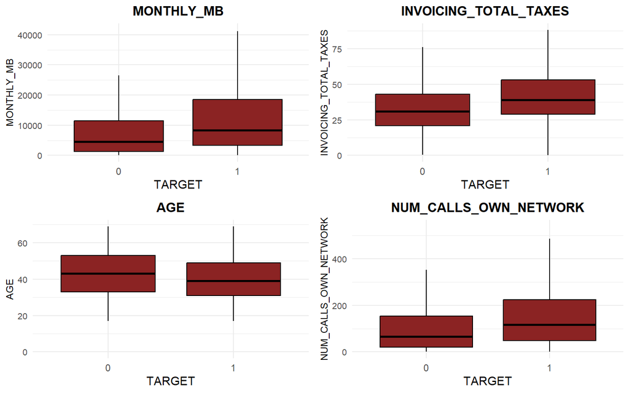

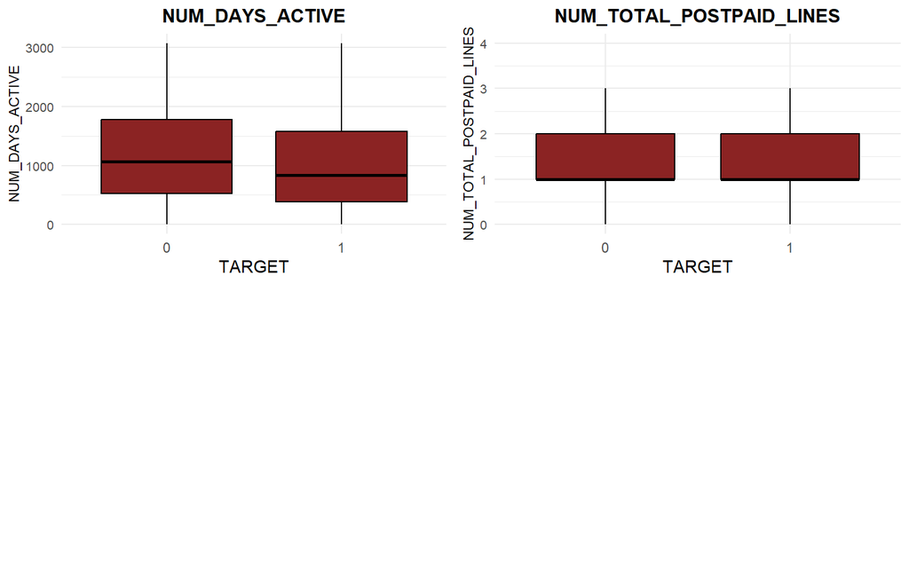

```r
selected_vars <- c("MONTHLY_MB", "INVOICING_TOTAL_TAXES", "AGE",
                   "NUM_CALLS_OWN_NETWORK", "NUM_DAYS_ACTIVE", "NUM_TOTAL_POSTPAID_LINES")

plots <- list()

for (var in selected_vars) {
  p <- ggplot(mobile_train, aes(x = as.factor(TARGET), y = .data[[var]])) +
    geom_boxplot(outlier.shape = NA, fill = "brown4", color = "black") +
    labs(
      title = var,
      x = "TARGET",
      y = var
    ) +
    theme_minimal() +
    theme(
      axis.title.y = element_text(size = 9),
      axis.text.y = element_text(size = 8),
      axis.text.x = element_text(size = 9),
      plot.title = element_text(size = 12, face = "bold", hjust = 0.5),
      plot.margin = margin(5, 5, 5, 5)
    ) +
    scale_y_continuous(limits = c(0, quantile(mobile_train[[var]], 0.95, na.rm = TRUE)))

  plots[[var]] <- p
}

split_plots <- split(plots, ceiling(seq_along(plots) / 4))

for (i in seq_along(split_plots)) {
  do.call(grid.arrange, c(split_plots[[i]], ncol = 2, nrow = 2))
}
```

### Preprocessing

The **pipeline** performs two main preprocessing tasks. First, it imputes missing values for all numeric variables using their median values. Second, it removes a predefined set of columns that are redundant, highly correlated, or deemed irrelevant for the analysis.

```r
impute_median <- function(data) {
  data %>%
    mutate(across(
      .cols = where(is.numeric),
      .fns = ~ ifelse(is.na(.), median(., na.rm = TRUE), .)
    ))
}


remove_unwanted_columns <- function(data) {
  data %>% dplyr::select(-c(
    "NUM_LINES_UNKNOWN_TECHNOLOGY",
    "NUM_FIXED_POSTPAID_LINES",
    "NUM_FIXED_POSTPAID_DEACTIVATIONS",
    "NUM_POSTPAID_LINES",
    "NUM_POSTPAID_SERVICES",
    "NUM_TOTAL_POSTPAID_LINES",
    "MB_TOTAL",
    "SECONDS_INCOMING_CALL_OWN_NETWORK",
    "INVOICING_TOTAL_WITHOUT_TAXES",
    "SECONDS_OUTGOING_CALL_OWN_NETWORK",
    "DAYS_FIRST_ACCOUNT",
    "MOBILE_CALL_MINUTES",
    "KPI_TAXES",
    "NUM_FIXED_DEACTIVATIONS",
    "NUM_DEACTIVATIONS",
    "PERCENTAGE_SECONDS_OWN_NETWORK",
    "INVOICING_TERM"
  ))
}


preprocess_data <- function(data) {
  data <- impute_median(data)
  data <- remove_unwanted_columns(data)
  return(data)
}


mobile_train_cleaned <- preprocess_data(mobile_train)
mobile_test_cleaned <- preprocess_data(mobile_test)
```

## GLM model development

We will now fit a Generalized Linear Model (GLM) from the **binomial family** because the **response variable is binary.** This means the target outcome has two possible categories. The binomial family is appropriate for modeling probabilities of such binary outcomes. Additionally, the **logit link function** is used, which transforms the predicted probabilities into log-odds, allowing the model to capture the relationship between the predictors and the log-odds of the target event.

### First model

The first model includes the next variables: `INVOICING_TOTAL_TAXES`, `AGE` and `MONTHLY_MB`.

```r
glm_base <- glm(TARGET ~ INVOICING_TOTAL_TAXES + AGE + MONTHLY_MB,
                data = mobile_train_cleaned,
                family = "binomial")
summ(glm_base, digits = 3)
```

| Observations | 14999 |
| --- | --- |
| Dependent variable | TARGET |
| Type | Generalized linear model |
| Family | binomial |
| Link | logit |

| χ²(3) | 625.289 |
| --- | --- |
| Pseudo-R² (Cragg-Uhler) | 0.057 |
| Pseudo-R² (McFadden) | 0.034 |
| AIC | 17978.919 |
| BIC | 18009.382 |

|  | Est. | S.E. | z val. | p |
| --- | --- | --- | --- | --- |
| (Intercept) | -0.613 | 0.068 | -8.978 | 0.000 |
| INVOICING_TOTAL_TAXES | 0.010 | 0.001 | 13.920 | 0.000 |
| AGE | -0.016 | 0.001 | -12.021 | 0.000 |
| MONTHLY_MB | 0.000 | 0.000 | 6.533 | 0.000 |

Standard errors: MLE

$$\text{logit}(P(\text{TARGET} = 1)) = -0.613 + 0.010 *
\text{INVOICING_TOTAL_TAXES}\\- 0.016 * \text{AGE} + 0.000 \cdot
\text{MONTHLY_MB}$$

The chi-squared statistic is 625.289, with a **p-value of 0.000**, indicating that the **model significantly improves** over a **null model** with **no predictors.** The model’s Akaike Information Criterion **(AIC)** is **17978.919**.

The model includes a statistically significant **intercept** with an estimate of **-0.613**. This value represents the **log-odds** of the dependent variable (the probability of making a purchase) being equal to 1 when all predictor variables are zero. A negative intercept suggests that the baseline probability of the event occurring is below 50%.

The variable `INVOICING_TOTAL_TAXES` has a positive estimated coefficient of 0.010. This implies that for every unit increase in invoicing total taxes, the log-odds of the dependent variable being 1 increase by 0.010. In simpler terms, higher invoicing total taxes are associated with an increased probability of the event occurring. This relationship is highly significant (p < 0.001), highlighting the strong contribution of this variable to the model.

For `AGE`, the estimated coefficient is -0.016, which indicates a negative relationship between age and the probability of the event. Specifically, for every additional year of age, the log-odds of the event decrease by 0.016, meaning that older individuals are less likely to exhibit the event (e.g., make a purchase). This effect is also highly significant (p < 0.001), demonstrating that age is a key predictor in the model.

Lastly, the variable `MONTHLY_MB` shows a positive estimated coefficient of approximately 0.000. While the effect size is small, it suggests a positive relationship between monthly data usage and the probability of the event. This means that even slight increases in data usage are associated with a higher likelihood of the event occurring. The variable’s significance (p < 0.001) underscores its importance in the model, despite the small magnitude of its effect.

To better see the effects of the variables, some graphs are displayed.

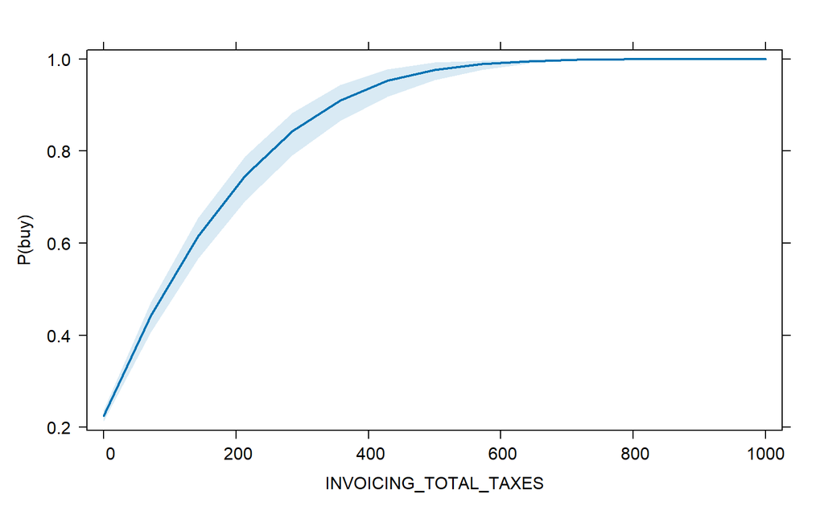

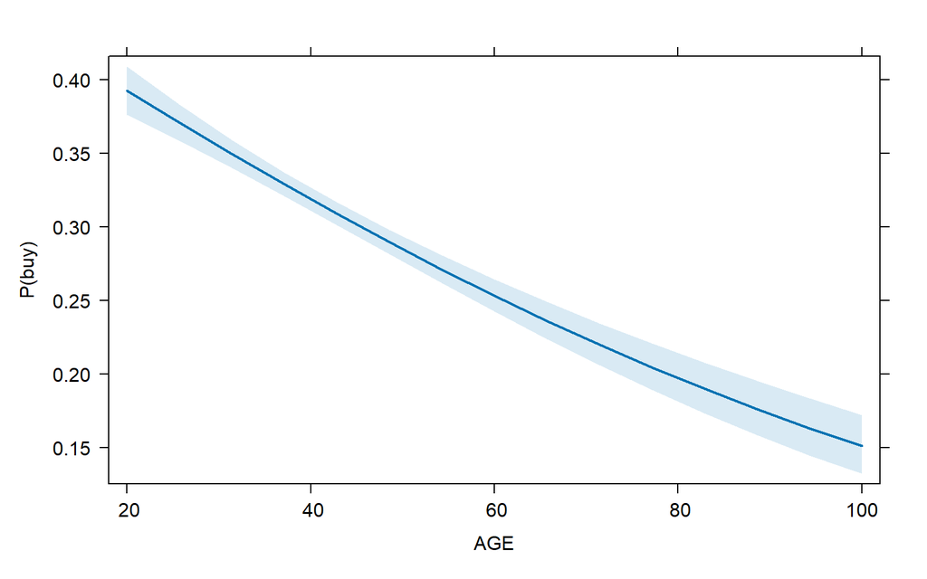

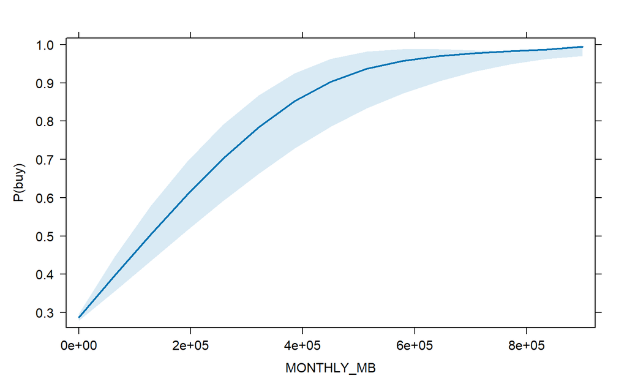

- **Graph 1:** This graph shows that as the total invoicing amount increases, the predicted probability of the customer making a purchase in the next month also rises. The relationship appears to be nonlinear, resembling an S-shaped curve, which is typical in logistic models.
- **Graph 2:** This graph indicates that the probability of making a purchase decreases as the customer’s age increases. The relationship seems to be linear and negative, suggesting a consistent decline in purchase probability with age.
- **Graph 3:** This graph demonstrates that as monthly data usage increases, the probability of making a purchase also increases. The relationship is quite similar to that of `INVOICING_TOTAL_TAXES`, likely because both variables reflect customer behaviour in terms of usage patterns. The shaded blue region represents the uncertainty interval (confidence band) around the predicted probabilities. At the extreme values of `MONTHLY_MB` (both very low and very high), the confidence band is narrower, indicating that the model’s predictions are more certain in these ranges. This pattern suggests that the model has greater confidence in the probabilities it predicts when monthly data usage is either minimal or very high.

Now, predictions are made using the test dataset to evaluate the model’s performance. In addition to assessing the model with the **AIC (Akaike Information Criterion)**, further evaluation metrics are used, including the **AUC (Area Under the Curve)** and the **ROC (Receiver Operating Characteristic)** curve. The AUC measures the model’s ability to distinguish between the two classes, with a value closer to 1 indicating better discrimination. The ROC curve graphically represents this performance by plotting the True Positive Rate (Sensitivity) against the False Positive Rate (1 - Specificity) at various threshold levels.

```r
mobile_test_cleaned$predicted_prob <- predict(glm_base, newdata = mobile_test_cleaned, type = "response")
mobile_test_cleaned$predicted_class <- ifelse(mobile_test_cleaned$predicted_prob > 0.5, 1, 0)
```

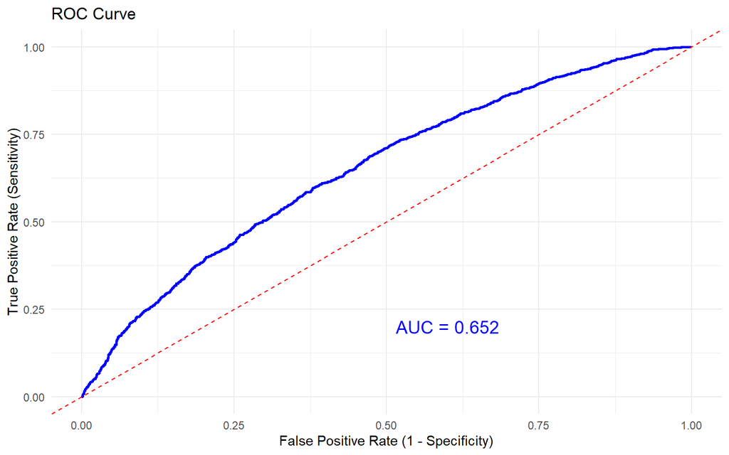

```r
conf_matrix <- confusionMatrix(as.factor(mobile_test_cleaned$predicted_class),
                               as.factor(mobile_test_cleaned$TARGET))

roc_curve <- roc(mobile_test_cleaned$TARGET, mobile_test_cleaned$predicted_prob)
auc_value <- auc(roc_curve)

roc_data <- data.frame(
  TPR = rev(roc_curve$sensitivities),
  FPR = rev(1 - roc_curve$specificities)
)

ggplot(roc_data, aes(x = FPR, y = TPR)) +
  geom_line(color = "blue", size = 1) +
  geom_abline(slope = 1, intercept = 0, linetype = "dashed", color = "red") +
  labs(
    title = "ROC Curve",
    x = "False Positive Rate (1 - Specificity)",
    y = "True Positive Rate (Sensitivity)"
  ) +
  theme_minimal() +
  annotate("text", x = 0.6, y = 0.2, label = sprintf("AUC = %.3f", auc(roc_curve)), color = "blue", size = 5)
```

The calculated **AUC** (Area Under the Curve) is **0.652**, indicating that the model has a moderate ability to discriminate between the two classes. An AUC of 0.652 means that, on average, the model correctly distinguishes between a randomly chosen positive and negative case 65.2% of the time.

```r
stats <- data.frame(
  Metric = c("Accuracy", "95% CI (Lower)", "95% CI (Upper)",
 "Sensitivity",
             "Specificity", "Pos Pred Value", "Neg Pred Value",
             "Balanced Accuracy"),
  Value = c(
    conf_matrix$overall["Accuracy"],
    conf_matrix$overall["AccuracyLower"],
    conf_matrix$overall["AccuracyUpper"],

    conf_matrix$byClass["Sensitivity"],
    conf_matrix$byClass["Specificity"],
    conf_matrix$byClass["Pos Pred Value"],
    conf_matrix$byClass["Neg Pred Value"],

    conf_matrix$byClass["Balanced Accuracy"]
  )
)

conf_table <- as.data.frame(as.table(conf_matrix$table))
colnames(conf_table) <- c("Prediction", "Reference", "Count")

stats %>%
  kbl(caption = "Evaluation metrics", row.names = FALSE) %>%
  kable_styling(full_width = F, bootstrap_options = c("striped", "hover"))
```

Evaluation metrics

| Metric | Value |
| --- | --- |
| Accuracy | 0.6912617 |
| 95% CI (Lower) | 0.6782491 |
| 95% CI (Upper) | 0.7040508 |
| Sensitivity | 0.9709724 |
| Specificity | 0.0719794 |
| Pos Pred Value | 0.6984757 |
| Neg Pred Value | 0.5283019 |
| Balanced Accuracy | 0.5214759 |

Once we have this first model we can add more variables and **interactions**.

### Second model

The second model includes: `AGE`, `MONTHLY_MB` and the interaction between `INVOICING_TOTAL_TAXES` and `NUM_MAIN_POSTPAID_LINES`.

```r
glm_invoicing_lines <- glm(TARGET ~ INVOICING_TOTAL_TAXES * NUM_MAIN_POSTPAID_LINES + AGE + MONTHLY_MB,
                           data = mobile_train_cleaned,
                           family = "binomial")
summ(glm_invoicing_lines, digits = 3)
```

| Observations | 14999 |
| --- | --- |
| Dependent variable | TARGET |
| Type | Generalized linear model |
| Family | binomial |
| Link | logit |

| χ²(5) | 746.679 |
| --- | --- |
| Pseudo-R² (Cragg-Uhler) | 0.068 |
| Pseudo-R² (McFadden) | 0.040 |
| AIC | 17861.529 |
| BIC | 17907.224 |

|  | Est. | S.E. | z val. | p |
| --- | --- | --- | --- | --- |
| (Intercept) | -1.499 | 0.111 | -13.542 | 0.000 |
| INVOICING_TOTAL_TAXES | 0.019 | 0.002 | 12.090 | 0.000 |
| NUM_MAIN_POSTPAID_LINES | 0.843 | 0.079 | 10.711 | 0.000 |
| AGE | -0.017 | 0.001 | -12.571 | 0.000 |
| MONTHLY_MB | 0.000 | 0.000 | 6.634 | 0.000 |
| INVOICING_TOTAL_TAXES:NUM_MAIN_POSTPAID_LINES | -0.008 | 0.001 | -8.392 | 0.000 |

Standard errors: MLE

$$\text{logit}(P(\text{TARGET} = 1)) = -1.499 + 0.019 *
\text{INVOICING_TOTAL_TAXES} + \\ 0.843 * \text{NUM_MAIN_POSTPAID_LINES}
- 0.017 * \text{AGE} + 0.000 * \text{MONTHLY_MB}\\ - 0.008 *
(\text{INVOICING_TOTAL_TAXES} \times \text{NUM_MAIN_POSTPAID_LINES})$$

The model is **statistically significant**, as indicated by the Chi-Squared test, and has an **AIC of 17861.529**. All variables and interactions included in the model are statistically significant. Importantly, the coefficients of the previously included variables remain consistent in both direction and significance.

The new variables provide additional insights: `NUM_MAIN_POSTPAID_LINES` (0.843) demonstrates that having more postpaid lines significantly increases the log-odds of the event, indicating a strong positive effect. However, the negative interaction term between `INVOICING_TOTAL_TAXES` and `NUM_MAIN_POSTPAID_LINES` suggests that the combined effect of these two variables diminishes as their values increase.

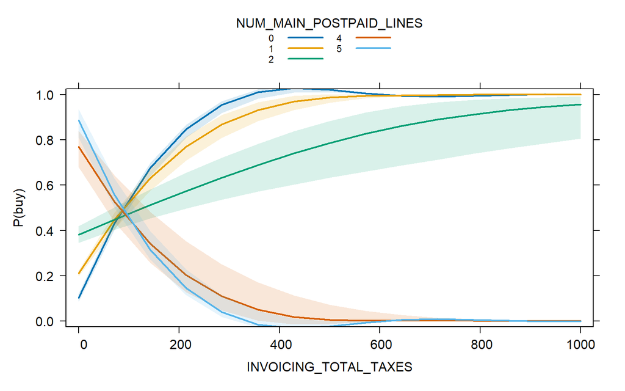

```r
plot(effect("INVOICING_TOTAL_TAXES * NUM_MAIN_POSTPAID_LINES", glm_invoicing_lines), ci.style="band", rescale.axis=FALSE, multiline=TRUE, ylab="P(buy)", rug=FALSE, main="")
```

This graph illustrates the interaction effect between `INVOICING_TOTAL_TAXES` and `NUM_MAIN_POSTPAID_LINES` on the predicted probability of a customer making a purchase. Each line represents a different level of `NUM_MAIN_POSTPAID_LINES`, while the x-axis corresponds to `INVOICING_TOTAL_TAXES`.

For customers with more postpaid lines (`NUM_MAIN_POSTPAID_LINES` = 4 or 5), the probability of purchase decreases as `INVOICING_TOTAL_TAXES` increases. This is shown by the downward-sloping lines for these groups. Conversely, for customers with fewer or no postpaid lines (`NUM_MAIN_POSTPAID_LINES` = 0 or 1), the probability of purchase increases with higher invoicing total taxes, as indicated by the upward-sloping lines.

The lines cross near lower values of `INVOICING_TOTAL_TAXES`. This suggests that at low invoicing levels, having more postpaid lines results in a higher probability of purchase. However, as invoicing increases, customers with fewer postpaid lines become more likely to purchase.

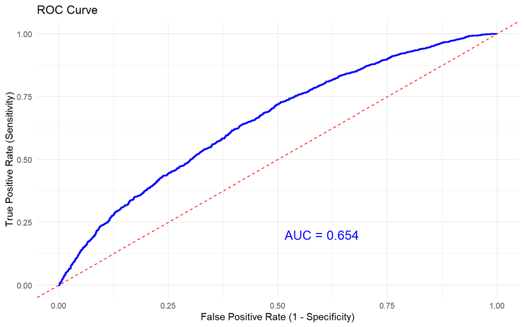

The calculated **AUC** (Area Under the Curve) is **0.654**, indicating an improvement over the basic model. This new model demonstrates better performance in terms of metrics, suggesting a more effective predictive capability.

Evaluation metrics

| Metric | Value |
| --- | --- |
| Accuracy | 0.6942611 |
| 95% CI (Lower) | 0.6812815 |
| 95% CI (Upper) | 0.7070137 |
| Sensitivity | 0.9602322 |
| Specificity | 0.1053985 |
| Pos Pred Value | 0.7038298 |
| Neg Pred Value | 0.5448505 |
| Balanced Accuracy | 0.5328153 |

Comparing the two models, there is a **slight improvement** in the metrics, but the overall performance issues remain.

Before proceeding with manually adding variables, a more systematic and automated variable selection process will be explored. This will ensure that only the most relevant variables are included in the model. It’s important to note that at this stage, interactions are not being included, and the focus remains solely on selecting the main effects to refine the model further. This approach aims to enhance model accuracy while maintaining simplicity and interpretability.

### Best feature selection

Best feature selection is applied.

```r
model_c <- glm(TARGET ~ ., data = mobile_train_cleaned, family = binomial)

model_s <- stepAIC(model_c, direction = "both", trace = FALSE)

summ(model_s, digits = 3)
```

| Observations | 14999 |
| --- | --- |
| Dependent variable | TARGET |
| Type | Generalized linear model |
| Family | binomial |
| Link | logit |

| χ²(15) | 1073.315 |
| --- | --- |
| Pseudo-R² (Cragg-Uhler) | 0.097 |
| Pseudo-R² (McFadden) | 0.058 |
| AIC | 17554.894 |
| BIC | 17676.746 |

|  | Est. | S.E. | z val. | p |
| --- | --- | --- | --- | --- |
| (Intercept) | -1.405 | 0.108 | -12.995 | 0.000 |
| INVOICING_TOTAL_TAXES | 0.002 | 0.001 | 2.457 | 0.014 |
| INVOICING_QUOTA | 0.015 | 0.003 | 5.496 | 0.000 |
| SECONDS_CALL_OWN_NETWORK | 0.000 | 0.000 | 3.303 | 0.001 |
| MONTHLY_MB | 0.000 | 0.000 | 2.314 | 0.021 |
| AGE | -0.018 | 0.001 | -12.480 | 0.000 |
| NUM_CALLS_OWN_NETWORK | 0.001 | 0.000 | 5.014 | 0.000 |
| NUM_MAIN_POSTPAID_LINES | 0.139 | 0.052 | 2.672 | 0.008 |
| NUM_DAYS_CONVERGENT | 0.000 | 0.000 | 2.551 | 0.011 |
| NUM_CANCELLATIONS | -0.096 | 0.021 | -4.581 | 0.000 |
| MOBILE_CALLS | 0.009 | 0.004 | 2.429 | 0.015 |
| NUM_DAYS_ACTIVE | -0.000 | 0.000 | -2.756 | 0.006 |
| NUM_BUNDLE_DAYS | 0.000 | 0.000 | 3.254 | 0.001 |
| TOTAL_BRAND_SERVICES | -0.071 | 0.044 | -1.626 | 0.104 |
| TOTAL_POSTPAID_SERVICES | 0.119 | 0.024 | 5.030 | 0.000 |
| ZONE_FIXED_PENETRATION | 2.084 | 0.260 | 8.008 | 0.000 |

Standard errors: MLE

The model is **statistically significant**, as indicated by the Chi-Squared test, and has an **AIC of 17554.89**. Key predictors influencing the model include `AGE`, which has a strong negative impact, indicating that older individuals are less likely to exhibit the target behaviour. Similarly, `NUM_CANCELLATIONS` negatively affects the outcome, suggesting that a higher number of cancellations reduces the likelihood of the event.

On the positive side, `ZONE_FIXED_PENETRATION` emerges as the most influential variable, showing that higher fixed penetration in a customer’s zone significantly increases the probability of the event. Other notable predictors include `NUM_MAIN_POSTPAID_LINES`, which highlights the importance of postpaid lines, and `INVOICING_QUOTA`, demonstrating that higher invoicing quotas are strongly associated with the target behaviour.

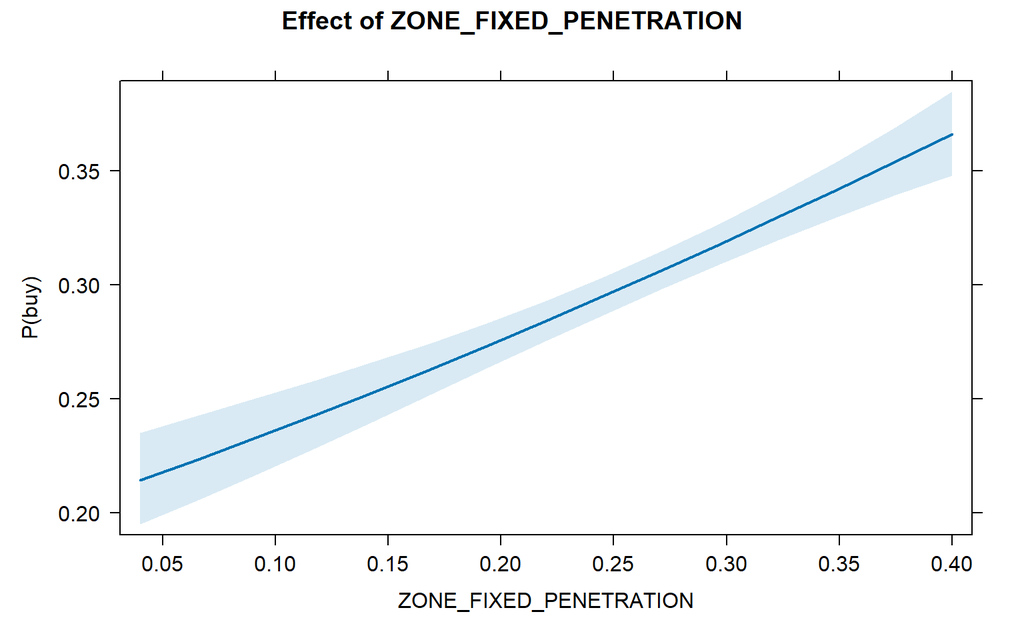

The Effect of `ZONE_FIXED_PENETRATION` graph is particularly important to analyze because this variable has the highest coefficient in the model, indicating its strong impact on the probability of purchase. A higher `ZONE_FIXED_PENETRATION` is associated with a significant increase in the likelihood of purchase. This suggests that the fixed-line penetration in a customer’s region plays a crucial role in influencing their behaviour.

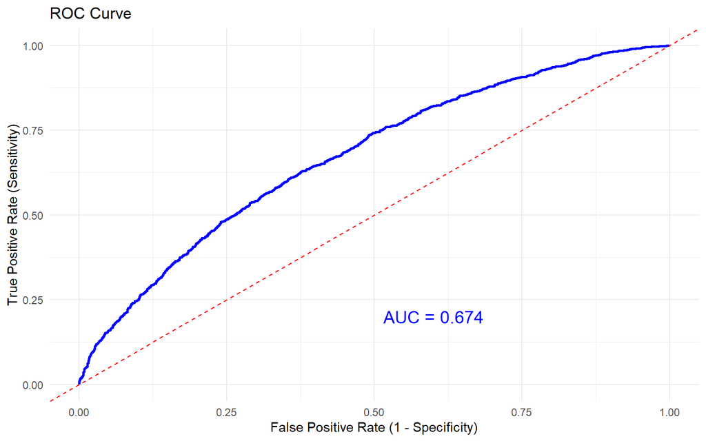

With an improved selection of predictors, the model achieves an **AUC** of **0.674**, which is higher than the AUCs obtained in previous models. This demonstrates that the refined set of predictors enhances the model’s ability to distinguish between the two classes, leading to better overall performance and more accurate predictions.

Evaluation metrics

| Metric | Value |
| --- | --- |
| Accuracy | 0.7028594 |
| 95% CI (Lower) | 0.6899778 |
| 95% CI (Upper) | 0.7155039 |
| Sensitivity | 0.9468795 |
| Specificity | 0.1625964 |
| Pos Pred Value | 0.7145674 |
| Neg Pred Value | 0.5802752 |
| Balanced Accuracy | 0.5547380 |

The final step involves building a model based on this improved predictor selection and adding relevant interactions.